# Effect Inflation: The Declining Purchasing Power of Published Small-N Findings

Life with Universally Huge Treatment Effects Would Be a Nightmare

Author

Rex W. Douglass PhD

Published

April 15, 2026

Rex W. Douglass PhD — rexdouglass.com — April 15, 2026

## 1 A Day in a Life of Huge Treatment Effects

Your morning starts with wild swings in trust for your spouse: up 11% from holding a warm cup of coffee, (Williams and Bargh 2008) then down 30% from the smell of last night’s kitchen trash. (Lee and Schwarz 2012) Uncertain about your marriage, you pick out a red shirt for the 10% bump on the attractiveness scale (Elliot and Niesta 2008) and head to work. There a power pose jacks your testosterone 30%, and putting your feet up on the desk makes you 43% more likely to take a risky bet. (Carney, Cuddy, and Yap 2010) Your inevitable meeting with HR is all but guaranteed by a dim room light that made you cheat on your reimbursement forms 47% above baseline. (Zhong, Bohns, and Gino 2010) To save your job and protect your health, you duck out of work early and head to the bar. The bottle of red wine reduces your cardiovascular mortality 30% and your all-cause mortality 20%. (Ronksley et al. 2011) Somehow you make it home and vow to do better the next day. You swallow a fistful of vitamin C, (Pauling 1971) echinacea, (Shah et al. 2007) zinc lozenges, (Prasad et al. 2008) and melatonin, (Petrie et al. 1989) all guaranteed to slash your colds and jet lag. Exhausted, you doze off to a podcast about there being yet another study proving the existence of ESP. (Bem 2011)

## 2 Huge Silly Treatment Effects are Hallucinations from a Broken Scientific Publishing Industry

Why does science keep popularizing obviously absurd claims about trivial things having large impacts? At least two reasons.

The first you’ve probably heard of: the *file drawer*. Researchers run many studies and only publish the ones that cross an arbitrary threshold of statistical significance. That’s the diagonal line in Figure 1. Studies below it mostly never appear; studies above it might. The bigger the sample size *N* (along the horizontal axis), the easier that threshold is to clear.

The second you might not have noticed. Small-*N* studies *cannot produce small-effect publications*. The arithmetic won’t allow it. A study with *N* = 40 has to report *d* ≥ 0.62 (Cohen’s *d*—treatment effect over outcome SD) to reach *p* < 0.05, regardless of what’s actually true about the world. So when small-*N* studies do publish, they publish huge effects—not because huge effects are there, but because nothing smaller can get through. The intro findings plotted here all sit in the top-left quadrant: unlikely effect sizes propped up by weak evidence.

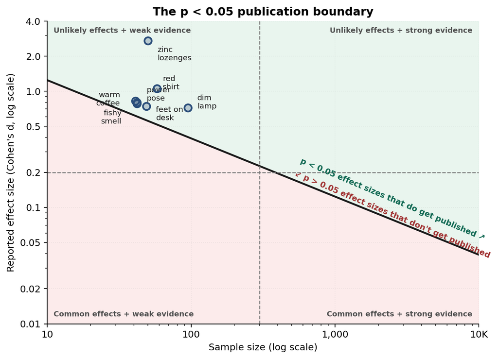

Figure 1: The p < .05 publication boundary. For a two-sample test, a study only clears the conventional threshold when observed D is roughly 2 * 1.96 / sqrt(N). The labeled points are the opening-scenario examples that map cleanly onto a single-study two-sample-style D-vs-N point.

## 3 It's Not Just the Silly Treatments — Most Huge Effects are Hallucinations

Below are 2,059 recovered original/replication endpoint pairs, now using the expanded local replication-pair build rather than the smaller draft table alone.

The pairs come from the major coordinated replication efforts: the Reproducibility Project: Psychology, Many Labs 1–5, the Social Sciences and Experimental Economics Replication Projects, the Reproducibility Project: Cancer Biology, DARPA SCORE, the Cova experimental philosophy replication, the Pipeline Project, and the Registered Replication Reports.

Figure 2 summarizes the current replication build. 79% of effects shrink, 40% shrink below the p < 0.05 boundary at the replication sample size, and the fitted log-log slope implies about 49% lower D for each 10x increase in N.

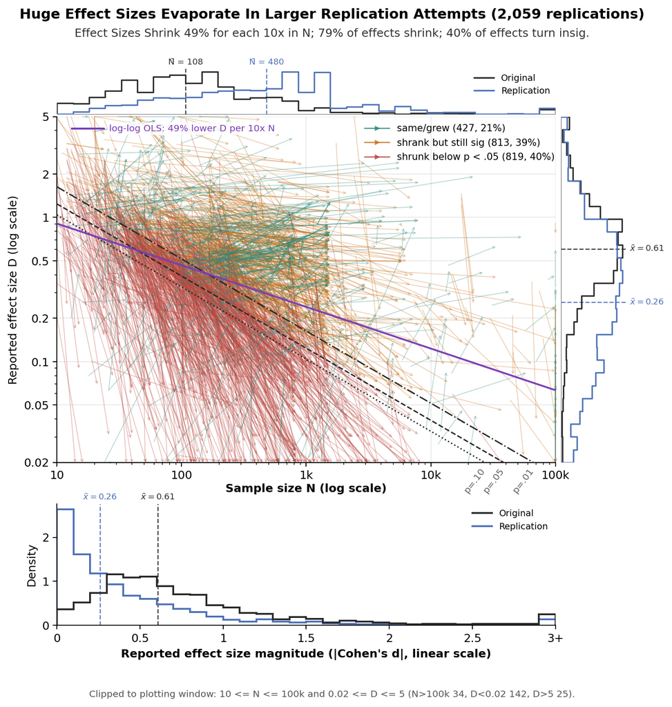

Figure 2: Huge effect sizes evaporate in larger replication attempts. The current recovered pair table contains 2,059 original/replication endpoint pairs; 79% shrink, 40% shrink below the p < .05 boundary, and the log-log fit implies about 49% lower D for each 10x increase in N. The marginal distributions replace the draft’s old separate before/after distribution figure.

**Selection criteria for Figure 2.** We keep only recovered original/replication effect pairs where both sides have a usable common-metric effect size on our shared $D$ axis, both sample sizes are known and at least 10, and the replication attempt is larger than the original ($N_r > N_o$). We also collapse obvious site-level repeats to one row per original paper × replication study × endpoint anchor, using summed replication $N$ and an $N$-weighted replication $D$. The unit here is therefore a paper-endpoint pair, not a paper: the current 2,059-row table comes from 1,132 unique original papers, and 324 of those originals contribute more than one row. That many-to-one structure is expected because one original paper can contribute several claims or outcomes, and some claims are re-tested by multiple labs or samples.

**Why use $D$ here, and what are its limits?** We use a shared $D$ axis because Figure 2 needs one magnitude scale that can compare many different literatures and endpoint types. Raw percent changes, relative improvements, and other denominator-sensitive summaries often explode when the baseline is tiny, so they are not stable enough for a cross-study distribution. A standardized effect like $D$ is a cleaner common axis for asking one narrow question: how large did the original claim look, and how large did the larger follow-up look, on the same scale? But $D$ is not neutral. It can be inflated when the pooled SD is unusually small, noisy, range-restricted, or measured in a selected subgroup. It also throws away natural units and can blur baseline risk or clinical importance. And when $D$ is back-converted from odds ratios, hazard ratios, cluster-adjusted models, or adjusted mean differences, the conversion adds another layer of assumptions. So we use $D$ here because it is the least bad common axis for this figure, not because it is a perfect one.

The originals are not approximations to the truth that better statistics could clean up. They are filter artifacts: numbers the publication boundary selected into existence. There’s nothing reanalysis can do. The only remedy is to rerun at large *N*.

When you read the next small-*N* paper claiming *d* = 0.8 from *N* = 40, this is what you’re looking at.

## 4 Most Effect Sizes Must be Small

The right question is not whether a published estimate crossed *p* < .05. The right question is: given what real effects usually look like, and given that this estimate survived a publication process that rewards large significant estimates, what should I now believe about the true effect?

The first input to that judgment is empirical, not philosophical. **Figure 2** gives us 2,059 recovered original/replication endpoint pairs, all on a common $D$ scale, all with both sample sizes known, and all with the replication larger than the original. In that sample, 79% of effects shrink, 40% shrink below the original *p* < .05 boundary at the replication sample size, and the fitted log-log relationship implies about 49% lower $D$ for each 10x increase in $N$. That distribution is not an oracle, but it is the least-filtered empirical prior available here: larger samples, direct retests, and far less room for the original publication boundary to select the observed magnitude.

The second input is structural. Appendix F lays out eleven reasons most effects must be small before we ever look at a *p*-value. The short version is that behavioral, biomedical, educational, and social outcomes are bounded noisy aggregates. They are produced by many causes, mediated through partial mechanisms, measured with finite reliability, diluted by active controls and counterfactual exposure, averaged across heterogeneous people and settings, and eroded by site-to-site voltage drop and scale-up decay (Tosh et al. 2025; Pearl 2022; MacKinnon et al. 2002; Spearman 1904; Hedge, Powell, and Sumner 2017; Bryan, Tipton, and Yeager 2021; Klein et al. 2018; Al-Ubaydli, List, and Suskind 2017; Pereira, Horwitz, and Ioannidis 2012a). Ordinary interventions usually push on one weak edge in a dense causal graph, not on a single unconstrained bottleneck.

The third input is statistical. A published estimate is not just a noisy draw from the world. It is a noisy draw that survived a significance filter. Gelman and Carlin’s Type M framework, van Zwet and Cator’s significance-filter analysis, and the broader winner’s-curse literature all imply the same direction of correction: conditional on significance, small noisy studies exaggerate magnitude (Gelman and Carlin 2014; E. W. van Zwet and Cator 2021; Ioannidis 2008; Loken and Gelman 2017). So a rational reader needs shrinkage, not just standard errors.

That is what **Figure 3** is for. The flat line is the implicit no-shrinkage prior: every effect from $d = 0.01$ to $d = 1,000$ treated as no less plausible than every other. The blue curve is the weakly informative Normal$(0, 0.35)$ prior. It does not ban large effects. It says they are rare enough to pay an evidentiary tax. About 95% of that prior lies inside $|d| < 0.69$. That is a reasonable public-facing approximation to what the replication distribution is already telling us.

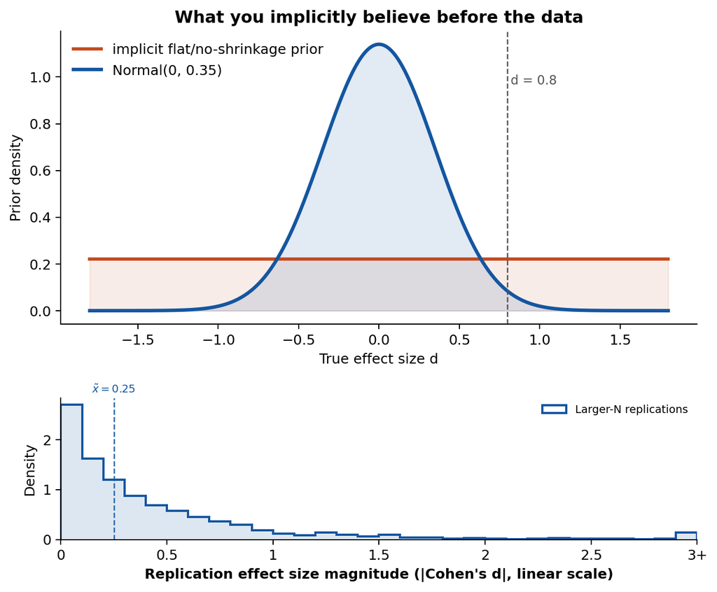

Figure 3: What you implicitly believe before the data. The flat/no-shrinkage line treats large effects as no less plausible than small effects; the Normal(0, 0.35) prior puts most mass on behavioral-science effects near zero. The lower panel shows the linear-scale distribution of larger-N replication effect sizes, with the median marked.

Write the update the simple way:

$$d \sim N(0, \tau^2), \qquad \hat d \mid d, s \sim N(d, s^2)$$

$$E[d \mid \hat d, s] = \frac{\tau^2}{\tau^2 + s^2} \hat d$$

with $\tau = 0.35$. For a balanced two-group design, a useful approximation is $s \approx 2 / \sqrt{N}$. That makes the reader-facing lesson immediate: large studies have small $s$, so the data dominate; small studies have large $s$, so the estimate shrinks hard toward zero. The prior does not make large effects impossible. It makes small-$N$ large effects earn their keep.

Take the kind of result this essay keeps attacking: a 40-person study reporting $\hat d = 0.80$. Then $s \approx 2 / \sqrt{40} \approx 0.316$. Under the Normal$(0, 0.35)$ prior, the shrinkage weight is

$$w = \frac{0.35^2}{0.35^2 + 0.316^2} \approx 0.55$$

so the posterior mean is not $0.80$. It is about $0.44$. Run the same observed estimate at $N = 400$, where $s \approx 0.10$, and the weight rises to about 0.92, giving a posterior mean of about $0.74$. That is the whole argument in one contrast. The prior is not saying “big effects never happen.” It is saying “a huge effect from a tiny study is mostly evidence about noise plus selection unless the underlying causal story is extraordinary.”

And that is exactly what the replication evidence shows. Small-$N$ literatures produce large selected estimates; larger replication attempts pull them back toward the effect-size range the world actually allows. Our Figure 2 estimate — 79% shrinking, 40% shrinking below the original significance boundary, and about 49% lower $D$ per 10x increase in $N$ — is not a side fact. It is the empirical prior the rest of the paper is asking the reader to use.

Real large effects still exist. But when they are real, they look like vaccines, antibiotics, or other interventions whose targets visibly collapse under coarse measurement and large-scale replication, not like vague primes in 42 undergraduates. That is why the burden of evidence rises with the size of the claim. If a result is supposed to live in the thin tail of Figure 3, then the evidence has to look tail-worthy too: large samples, hard outcomes, active controls, repeated success across sites, or effects obvious enough to see without statistical heroics.

## 5 A World In Which Most Published Research Was True Would Be A Nightmare Hellscape

Take the published literature at face value for a moment. Suppose large effect sizes did not require large evidence, and a 40-person undergraduate study reporting *d* = 0.8 were about as informative about reality as a 40,000-person preregistered RCT reporting the same thing. In that world, sample size would be a cost consideration, not an epistemic one.

But then this is not just a cloud of papers. It is a map of a world.

What would the published record look like in that world? Figure 4 shows 10,507 published-original candidate papers across 26 source corpora, with each paper represented by its median $D$ and median $N$ in the top panel and the same published paper-level estimates summarized underneath.

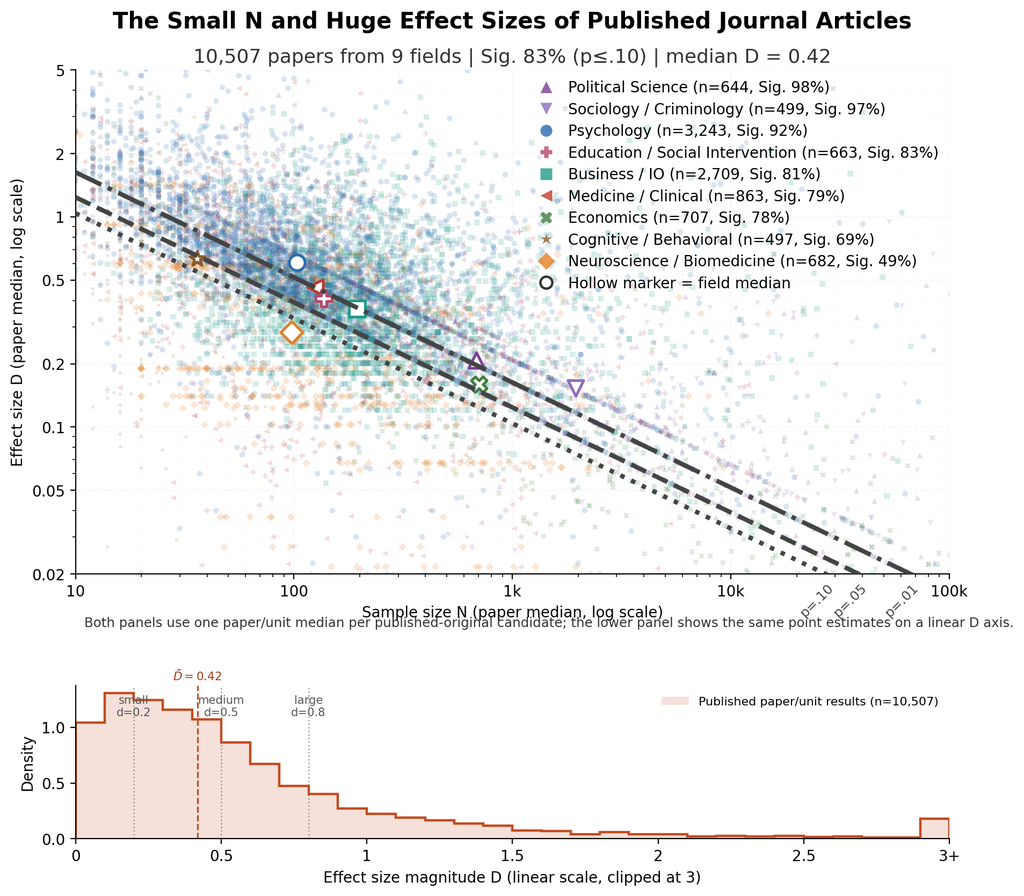

Figure 4: The small-N and huge-effect-size pattern in published journal articles. The top panel shows 10,507 published-original candidate papers across 26 source corpora as paper/unit medians; the lower panel shows the distribution of those same published paper/unit estimates. The paper-level median D is 0.42, median N is 160, and 83% sit above the p <= .10 boundary.

In this corpus, 76.5% of papers have median $D \ge 0.2$, 41.8% have median $D \ge 0.5$, and 21.7% have median $D \ge 0.8$. That is 8,040 nontrivial effects, 4,390 medium-or-larger effects, and 2,281 conventionally large effects. Read literally, the literature is not saying that large effects sometimes happen. It is saying that large effects are ordinary.

But 2,281 is not the implication. It is only the sample count. If this published distribution were a truthful window into the indexed scientific literature, it would scale into a claim about hundreds of thousands to millions of large-effect papers.

Let $J$ be the number of journal articles in the indexed literature and $q$ the fraction of them that are relevant empirical effect-estimating papers. Taking Crossref’s roughly 123.1 million journal DOI records and the current 21.7% large-effect share as an order-of-magnitude benchmark, the implied number of paper-level $D \ge 0.8$ claims is

$$L_{0.8} = 0.217 q J.$$

| Universe assumption | Relevant empirical / effect papers | Implied $D \ge 0.8$ paper-level large-effect claims |
| --- | --- | --- |
| Crossref journal records, only 2% relevant | 2,462,000 | 534,484 |
| Crossref journal records, only 4% relevant | 4,924,000 | 1,068,968 |
| Crossref journal records, 10% relevant | 12,310,000 | 2,672,419 |
| Crossref journal records, 25% relevant | 30,775,000 | 6,681,048 |
| 2023 worldwide S&E output, 10% relevant | 330,000 / year | 71,641 / year |
| 2023 worldwide S&E output, 25% relevant | 825,000 / year | 179,102 / year |

The “millions” claim does not require pretending that all science is psychology or medicine. If only 4% of indexed journal articles are in the relevant class, the published distribution implies about 1,068,968 paper-level $D \ge 0.8$ claims. If 10% are relevant, it implies about 2,672,419. If 25% are relevant, it implies about 6,681,048. At the annual scale, even a 10% relevant-share assumption implies roughly 71,641 new conventionally large effects per year.

Some of those papers are studying the same underlying effect, so paper-level claims are not the same thing as unique causal levers. But duplication has to be enormous to save the literal interpretation. If each genuine large effect generated five papers, the 10% Crossref scenario still implies about 534,484 unique $D \ge 0.8$ effects, and the 25% scenario still implies about 1,336,210. The exact duplication correction is unknown. The scale is the point.

That is a data-generating-process claim, not just a bibliometric one. For a balanced two-group comparison,

$$r = \frac{d}{\sqrt{d^2 + 4}}, \qquad R^2 = \frac{d^2}{d^2 + 4}.$$

So a $d = 0.2$ effect corresponds to about $r = 0.10$ and explains about 1.0% of outcome variance. A $d = 0.5$ effect corresponds to about $r = 0.24$ and explains about 5.9% of outcome variance. A $d = 0.8$ effect corresponds to about $r = 0.37$ and explains about 13.8% of outcome variance. Roughly one hundred independent $d = 0.2$ levers, seventeen independent $d = 0.5$ levers, or seven independent $d = 0.8$ levers pointed at the same outcome would use up essentially the whole variance budget. The exact arithmetic changes with dependence, heterogeneity, and measurement, but the qualitative point does not: you cannot have a world in which every small intervention is a giant intervention. The variance has to come from somewhere.

Nor is $d = 0.8$ a subtle effect. Under the usual equal-variance model,

$$P(Y_T > Y_C) = \Phi(d / \sqrt{2}).$$

At $d = 0.5$, a random treated observation beats a random control observation about 64% of the time. At $d = 0.8$, it is about 71%. One large effect is survivable. But it is no longer a nudge. It is a major axis of the outcome.

The problem is accumulation. In an unbounded additive model, let

$$Y = dT + \epsilon,$$

with balanced treatment assignment and $\epsilon$ variance fixed at 1. Then one $d = 0.8$ lever raises the outcome variance from 1 to $1 + .25d^2 = 1.16$, so the outcome SD rises by about 7.7%. But with $K$ independent $d = 0.8$ levers,

$$\operatorname{Var}(Y) = 1 + 0.16K.$$

| Independent $d = 0.8$ levers | New SD if residual SD stays fixed | Apparent $d$ of each original lever after variance inflation |
| --- | --- | --- |
| 1 | 1.08x | 0.74 |
| 5 | 1.34x | 0.60 |
| 10 | 1.61x | 0.50 |
| 20 | 2.05x | 0.39 |
| 50 | 3.00x | 0.27 |
| 100 | 4.12x | 0.19 |

That table is the DGP problem in miniature. If you keep adding real independent $d = 0.8$ effects, either the outcome variance balloons or each effect stops being $d = 0.8$ relative to the new world. You cannot have thousands of simultaneously real, independent, population-level $d = 0.8$ levers on ordinary stable outcomes.

Most real outcomes do not have arbitrary variance. Test scores, depression scales, blood pressure, turnout, BMI, cholesterol, trust ratings, and reaction times have empirically stable distributions. In that fixed-variance world, a large effect does not inflate the outcome. It spends the variance budget instead. A $d = 0.8$ causal variable explaining 13.8% of outcome variance is not “one more thing that matters.” It is one of the main things that matters. Seven independent effects that large exhaust almost the whole budget. Seventeen $d = 0.5$ effects do the same. In a fixed-variance world, a large effect is not a nudge. It is a pillar of the DGP.

The same point looks even harsher for binary outcomes. Using the standard logistic approximation,

$$\log(OR) \approx d \frac{\pi}{\sqrt{3}}.$$

So $d = 0.8$ corresponds to an odds ratio of about 4.27. Start with a 10% event probability and apply repeated independent $d = 0.8$ levers:

| Number of independent $d = 0.8$ levers | Probability after applying $OR \approx 4.27$ each |
| --- | --- |
| 1 | 32.17% |
| 2 | 66.93% |
| 3 | 89.62% |
| 4 | 97.36% |
| 7 | 99.97% |

For a binary DGP, “explosion” means saturation. Probabilities race toward 0 or 1. After a handful of large effects, the outcome is no longer a noisy, resistant human outcome. It is almost determined.

The same is true on bounded scales. If controls are normally distributed with mean 0 and SD 1, then $P(Y > 1)$ is 15.9% and $P(Y > 2)$ is 2.3%. After a $d = 0.8$ shift those become 42.1% and 11.5%. A large effect does not merely move the average. It turns rare states into common states. If thousands of ordinary interventions did that, everyday distributions would visibly lurch toward ceilings and floors whenever ordinary inputs changed.

And the large-effect claim does not get rescued by heterogeneity. If only fraction $h$ of people are true responders and everyone else has zero effect, then an average $d = 0.8$ requires a responder-only shift of roughly $0.8 / h$:

| Responding fraction | Responder-only effect needed for average $d = 0.8$ |
| --- | --- |
| 100% | 0.8 |
| 50% | 1.6 |
| 20% | 4.0 |
| 10% | 8.0 |

If the effect is broad, it consumes the population variance budget. If it is narrow, then responders have to move by multiple standard deviations. Either way, it should be obvious.

The small-$N$ publication boundary explains why the literature can look this way without that world existing. For a balanced two-group design,

$$s_{\hat d} \approx \frac{2}{\sqrt{N}}, \qquad |\hat d| \gtrsim \frac{3.92}{\sqrt{N}} \text{ for two-sided } p < 0.05.$$

That makes the significance rule itself an effect-size filter. At total $N = 20$, the minimum publishable $|\hat d|$ is about $0.88$. At $N = 40$, it is about $0.62$. At $N = 80$, about $0.44$. At $N = 200$, about $0.28$. At $N = 400$, about $0.20$. At small $N$, “statistically significant” already means “observed effect size large enough to look exciting.”

This is why three different empirical literatures keep converging on the same correction. Szucs and Ioannidis found that published cognitive-neuroscience and psychology papers were packed with large nominal effects and low power (Szucs and Ioannidis 2017). Pereira, Horwitz, and Ioannidis found that very large medical effects usually came from small first trials and shrank sharply as more evidence accumulated (Pereira, Horwitz, and Ioannidis 2012a). Registered Reports cut the positive-result rate dramatically once publication decisions were made before the data were known (Scheel, Schijen, and Lakens 2021), and the antidepressant-trial record shows the same thing from the registry side: the published literature looked much more positive than the underlying FDA file (Turner et al. 2008). The point is not that one field cheated more than another. The point is that small samples plus a significance filter manufacture a literature full of apparently large, apparently decisive effects.

That life is one in which your fate is dictated by trivia, most of it outside your control. A warm cup, a stray smell, an overhead bulb — each a lever big enough to swing trust, honesty, testosterone, or the odds of a heart attack. Keeping a marriage, a job, or a working cardiovascular system would be a daily gauntlet: meticulous planning to control the inputs, and persistent luck when you couldn’t. No equilibrium you built over years of practice, effort, or cooperation would be stable, because any small thing could knock it over. Choosing the wrong shirt could cost you the promotion. Sitting in the wrong chair could cost you the deal. The right cup of coffee could save your marriage. The wrong one could end it.

And if every small thing mattered, then in another sense nothing would. You couldn’t decide what was worth your attention, because the list of things with life-sized consequences would be infinite. You couldn’t learn from experience, because each day’s outcome would be dominated by a different lurking confounder. You couldn’t give advice to your children, because whatever rule you landed on would be overturned by the next trivial intervention to come down the pike. A world in which everything is a huge treatment effect is a world in which agency, planning, and accumulated knowledge collapse into noise.

So the nightmare world is a reductio. If the published small-$N$ effect-size distribution were literal, reality would be packed with hundreds of thousands to millions of large, easy, high-variance causal levers. Ordinary DGPs cannot absorb that. They either inflate in variance, saturate at boundaries, collapse probabilities toward 0 or 1, or reveal that the supposedly independent effects are really the same few mechanisms wearing different names. The sane alternative is the boring one: most published small-$N$ large effects are not real large effects. We are lucky the literature is mostly not true.

## 6 How This Weirdly Unscientific Culture Became Normal

Humans keep inventing this worldview. In every era, in every culture, some version of it shows up: your fate is dictated by forces outside your control — the stars, the gods, karma, ancestors, trauma, your microbiome, your vibration — and also every small thing you do is loaded with ultimate consequence (Brenan 2005). You are simultaneously helpless and supernaturally responsible, and the contradiction is the point; a doctrine that resolved cleanly into either fatalism or agency would lose half its customers. The meme is stable because it pays two constituencies at once. For the individual it is the most flattering theory of the self ever invented: when things go well, you worked the system; when things go badly, the system (or karma (Lerner 1980), or someone else’s negative energy) worked you. Vague enough personality claims feel personally true to almost everyone (Forer 1949). For predatory institutions the same structure is a revenue model, because if every small thing matters and the mechanisms are invisible, the list of fixes someone can sell you is infinite. Religions sold indulgences on this logic for centuries (Galpern and Bossy 1986); prosperity preachers sell seed-faith donations on it now (Bowler 2013); a $6.8-trillion global wellness industry sells supplements, cleanses, and energy work (Institute 2023); MLM uplines sell the dream that the right mindset produces the right income, and most participants make little or no money doing it (Staff 2018). The product varies; the sales pitch is identical — *there is a hidden lever, you have been pulling it wrong, and I can show you how.* The pitch only works in a world of huge treatment effects. In a world of small, noisy, hard-won effects, no one needs a guru.

### 6.1 What a flat prior commits you to

Strictly speaking, NHST does not have a prior. That is part of the problem. A *p*-value is not (P(H_0 | data)), and a confidence interval is not born as a posterior distribution over the true effect. But when readers convert a significant estimate and its confidence interval into belief about the true effect, the object they are tacitly using is the flat-prior posterior in disguise. In the normal approximation, δ̂ | δ ∼ *N*(δ, *s*²); combine that likelihood with the improper prior π(δ) ∝ 1 and the posterior is δ | δ̂ ∼ *N*(δ̂, *s*²) — the same Gaussian bell that the confidence distribution traces. That is the no-shrinkage prior: not a probability distribution, not normalizable, and perfectly happy to assign equal density to equal-width intervals around *d* = 0.2, *d* = 5, and *d* = 1,000. No one believes this out loud. **Figure 3** draws what the belief would look like. The publication system behaves as if authors and reviewers were doing exactly that calculation.

NHST contains no prior at all. The flat prior appears when readers read a significant estimate and its confidence interval as a belief distribution over the true effect—which is how unshrunk point estimates routinely get read. With that implicit flat prior, a significant *p*-value at *n* = 30 is treated as evidence for an effect. A reasonable prior — one that puts, say, 95% of its mass in |*d*| < 0.7, because that’s where psychology-sized effects actually live — would demand far more data before allowing the same conclusion. The flat prior removes this brake, and the consequence is the gamification of discovery: instead of asking “how much data do I need to detect a psychologically plausible effect,” a researcher asks “how little data can I get away with and still clear the threshold.” The answer is often remarkably little — thirty subjects, if the effect you report is big enough. Coupled with the publication filter, where journals print the papers that clear *p* < 0.05 and not the ones that don’t, you end up with a literature that consists almost entirely of studies that had to report implausibly large effects in order to exist, and almost none that reported the actual small effects that were there. The published record contains the untrue things and excludes the true ones. Figure 1 and Figure 3 together are the mechanism. Figure 5 is what the mechanism produces.

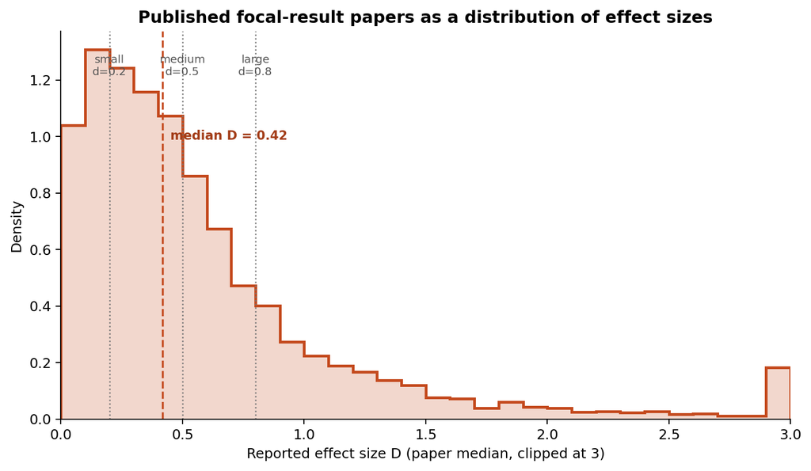

Figure 5: The current published-original candidate corpus as a distribution of paper-level effect sizes. 77% of papers have median D >= 0.2, 42% have median D >= 0.5, and 22% have median D >= 0.8.

Once that worldview is culturally normal, the rest of the machinery is easy to justify: tiny studies, huge estimates, confident prose, and a literature calibrated to discovery theater rather than measurement.

## 7 Objections

*Four objections are worth taking seriously. None of them saves the literature this essay is about.*

### 7.1 “But there are exceptions where effects really are large.”

Appendix B catalogs the exceptions in detail. The taxonomy is not alphabetical and not by academic field; it is by architectural type. Infectious disease control. Deficiency replacement. Mechanical and structural interventions. A handful of cardiovascular and metabolic pharmacologic classes. A short list of psychiatric interventions with clear mechanistic targets. A few educational interventions that happen to combine intensity, targeting, and a weak counterfactual. Behavioral policy interventions that change defaults rather than minds. Agricultural and environmental interventions that address a genuine limiting factor.

What these share is the shape of the compound model with each factor pushed favorably. A dominant causal bottleneck means *k* is effectively 1, so 1/√*k* is not small. A short causal chain means the product of path coefficients is close to 1. A large counterfactual gap means the control arm’s shared-ingredient fraction is close to 0. A well-measured proximal outcome means *r<sub>xx</sub>* is close to 1. When all four structural factors are favorable and the intervention is tested rigorously enough that the selection filter does no work, the effect can be enormous. Antibiotics against susceptible pathogens produce *d*-equivalents that do not fit on normal charts. Insulin moved life expectancy in Type 1 diabetes from months to decades. Cataract surgery restores sight.

The pattern of exceptions is the strongest possible confirmation of the rule. Large effects require specific structural conditions. Those conditions are rare. Their rarity is why most effects are small. Interventions that meet the full checklist are not distributed uniformly across human problems; they cluster in a few therapeutic areas (infection, deficiency, mechanical dysfunction) and a few behavioral domains (default architecture, choice of instruction intensity). Outside those clusters, the expected effect of any intervention is small, and researchers who report large effects should be read as having either (a) found a rare genuine exception that satisfies the checklist, or (b) produced an estimate that will not survive contact with replication, scale-up, or bias correction.

### 7.2 “It’s just p-hacking. Fix the filter and the rest takes care of itself.”

Fix every form of p-hacking tomorrow. A two-arm behavioral study with *N* = 40 still crosses *p* < 0.05 on an observed *d* of roughly 0.62, still has 23% power against a true *d* = 0.4, still selects upper-tail draws from its sampling distribution. Type M inflation on a small-*N* significant finding is approximately 2× under fully honest analysis—a property of the sampling distribution, not of researcher behavior.

Registered Reports make this concrete. Scheel, Schijen, and Lakens (Scheel, Schijen, and Lakens 2021) compared 71 preregistered Registered Reports to 152 standard articles and found positive-result rates of 96% versus 44%—a 52 percentage-point drop once p-hacking is removed by design. But 44% of honestly-analyzed studies still cross significance, in a world where most true effects are under *d* = 0.25. Those positive findings are inflated upper-tail draws. They still don’t replicate cleanly.

The filter is not the primary disease. The primary disease is that the resolution of the instrument doesn’t match the size of the object being measured. Remove p-hacking and you trade a literature of inflated positives for a literature of honest small-sample noise plus the rare large effect. Cleaner, but not informative.

### 7.3 “Researchers calibrate sample size to the true effect.”

This is the anthropic principle: investigators have priors about effect sizes, run power analyses, and size their *N* accordingly. A published *N* = 40 reflects an investigator who had reason to expect a detectable effect at that sample.

The best version of this objection is van Zwet, Gelman, and Więcek (G. van Zwet E. and Więcek 2026), whose model of 80,000 studies across 11 curated corpora includes exactly this claim. Their data refute it.

Across their corpora—Cochrane, clinical trials, ecology, political science, exercise research, economics, psychology, psychotherapy, education, intelligence—**3–11% of studies achieve 80% probability of significance**. Not eighty percent of studies. Three to eleven. Political science: 7%. Cochrane: 10%. Exercise and cognition: 3%. The modal published study is radically underpowered for the effect it is nominally detecting. vZGW’s own interpretation is that researchers size studies “just about large enough to assess the direction of the effect of interest, but not larger”—under pressures of time, money, and logistics.

That is not calibration. It is the minimum sample required to cross the filter on a favorable noise draw, which is exactly what the rest of this essay has argued. The anthropic principle is real; it does not say what the objection needs it to say. It says researchers size for filter-crossing, not for detection.

### 7.4 “At least the sign is right.”

The sharpest version of this objection is vZGW (G. van Zwet E. and Więcek 2026). Their model reports that published significant findings carry the correct sign 82–96% of the time at |*z*| = 1.96 and 94–99% at |*z*| ≥ 1.96, across all 11 of their curated corpora. Their interpretation: *“empirical research often leads to true findings—in the sense of correctly identifying the direction of an effect—that do not replicate in the sense of achieving statistically significant result in the same direction as the original study.”* Magnitudes are inflated; direction is informative; the replication crisis is overstated.

This is wrong, and the way it is wrong is instructive.

**The numbers are not a measurement.** They are the output of a model. vZGW fit a mixture of half-normals to the observed |*z*| distribution in each corpus, apply a Hedges single-parameter correction for publication bias, deconvolve out a standard normal noise component, and read off a posterior distribution over the true SNR. The 82–96% correct-sign figure is what that posterior implies under the model’s assumptions. It is not the result of comparing published signs to any external ground truth.

**The model’s central assumption fails in exactly the subfields where the crisis lives.** The assumption is that observed *z* equals true SNR plus standard normal noise. For this to hold, the published estimate must be an unbiased draw from its sampling distribution. That assumption holds when the study is well-identified: the construct is measured cleanly, the intervention is delivered as described, selection into the sample is exogenous, the analysis is fixed in advance. In that regime, upper-tail draws that cross the filter are disproportionately sign-concordant with the true effect, because the true mean and forward-direction noise point the same way. Correct sign 90% of the time falls out.

The assumption does not hold when the research process itself has degrees of freedom correlated with direction—specification selection, construct misspecification, demand characteristics, identification strategies that don’t identify what they claim. In that regime, the “noise” is not symmetric around the true effect. It is drawn from the space of specifications the researcher was willing to report. The filter still selects upper-tail draws, but those draws align with **what the researcher expected to find**, not with reality. A field that operates on a wrong shared prior produces a literature full of findings pointing in the theory-predicted direction, regardless of whether the theory is correct. vZGW’s model reads the resulting internal consistency as “high correct-sign rate.” It is not. It is internal consistency with a wrong prior.

**The direct empirical test defeats the model where it matters.** vZGW’s model does not have access to the true sign of the effect. Large preregistered replications do, at least approximately, because they restore the conditions under which observed *z* really is an unbiased draw. Run the test:

- Chabris et al. 2012 (Chabris et al. 2012): 12 previously-published candidate-IQ-gene effects tested in roughly 10,000 subjects. Replicated: **zero**. A coin produces six. Published sign correct rate: 0%.
- Duncan and Keller 2011 (Duncan and Keller 2011): 103 novel psychiatric G×E findings, 10 direct replications, 27% replication rate, pair-level sign match near 50%. Coin-equivalent.
- The Registered Replication Report program and Many Labs 3: ego depletion, facial feedback, professor priming, elderly priming, warmth priming—in aggregate, sign concordance with originals in the 40–60% range.

**This is not a “different subfield” problem.** It is a model-specification problem. vZGW’s framework cannot distinguish a literature that gets the sign right 90% of the time from a literature that is internally consistent 90% of the time in the direction of a wrong theory. Their model assumes the first; their data are compatible with either; the fields where the assumption is testable show the second. Their optimism is what their model outputs when their assumption is satisfied. In the fields where that optimism would actually matter, the assumption fails.

The replication crisis is not about magnitudes being imprecise while directions remain true. It is about the research process in specific subfields producing published literatures that do not carry reliable information about reality—not about magnitude, not about sign. vZGW have described a mathematical property of their model. They have not described the literature.

## 8 Appendix F — Why most effects must be small

Start with a contradiction. Suppose every intervention had a large effect. Every vitamin, every parenting choice, every policy, every supplement, every app notification, every teacher, every workout, every therapeutic technique, every political ad, every workplace intervention—every one of them moved the outcome by a full standard deviation. That world cannot exist. It cannot exist because the outcome you are moving—your cholesterol, your child’s test score, your depression rating, the country’s vote share—only varies by so much. There is a finite amount of standard deviation to be moved. If one thing moves it by a full SD, most other things can move it by almost nothing, because the variance budget is already spent. You can have a few big effects or many small ones; you cannot have many big ones. This is arithmetic, not psychology.

Real life is a standing refutation of the large-effects world. If every new drug had a large effect, pharmaceutical R&D would not spend a billion dollars per approval to find one that works (Scannell et al. 2012). If every teaching method had a large effect, there would be no education gap. If every diet had a large effect, obesity would be trivially curable. If every therapy had a large effect, mental illness would be rare.

Scale it up. If every nudge worked at the pilot-study scale, behavioral economics would have solved climate change, voter turnout, and retirement saving by lunch. If every published psychology finding reproduced at its published magnitude, a forty-person undergraduate study that reported a Cohen’s *d* of 0.8 from a two-minute intervention would represent a manipulation of humans as powerful as a strong drug. The literature as published describes a world in which nothing is hard: no diseases resist treatment, no students resist teaching, no behaviors resist nudging, no habits resist self-help. That world does not resemble any actual country, classroom, clinic, or household. The outcomes behavioral and biomedical science measure are, by definition, the ones that resist easy movement. That is *why* they are the ones being studied.

The rest of this section makes the argument precise in three layers, then shows that measurements confirm it.

*The first layer is about the outcomes themselves.* Why do mood, weight, test scores, and blood pressure have finite, predictable variance in the first place? And why do the outcomes that *don’t* — earthquakes, financial crashes, viral cascades — permit single interventions to produce very large effects?

*The second layer is about the causes.* Given a bounded outcome, the mechanisms that move it have to be small. Five bounds show how small and why.

*The third layer is about the research ecosystem.* Published studies pass through a significance filter that inflates what survives, a demand structure that contaminates every lab experiment, and a set of scaling frictions that keep pilots from reproducing. Eleven mechanisms in all; six admit exact derivations. Three independent empirical literatures then confirm the total size of the resulting gap.

### 8.1 Why outcomes are bounded at all

Before we get to estimation—before Gelman on selection, Pearl on mediation, or Spearman on reliability—there is a prior question. Why is there a stable, measurable “effect of *X* on *Y*” at all? Why does shoving a complex system produce a reproducible, finite displacement rather than chaos, runaway, or nothing? The answer is not a fact about statistics; it is a fact about the systems we study. Five properties rule out the world of arbitrarily large effects, and each of them can be seen through a thought experiment: imagine the property didn’t hold, look at what reality would have to look like, and notice that it doesn’t.

*Outcomes are aggregates.* Blood pressure, test score, depression rating, vote share, GDP, body weight—every outcome behavioral and biomedical science measures is a sum or average over enormous numbers of underlying micro-events. The central limit theorem then squeezes the distribution of any such aggregate toward a bell with finite variance. *Suppose this weren’t true.* Then a single neuron firing or a single cell dividing could shift the whole outcome; your blood pressure this morning would be uncorrelated with your blood pressure yesterday; the class average on the retest would have no systematic relationship to the class average on the first test. Talking about “the mean” of anything would be nonsense, because the next measurement would wander anywhere. We know outcomes don’t behave this way because *re-measuring* the same person or the same group gives a similar number. The aggregation that makes re-measurement meaningful also fixes the variance and caps what any single input can do.

*Systems dissipate.* Biological, social, and mechanical systems lose energy to friction, noise, and entropy; perturbations decay, usually exponentially, with a timescale set by the system’s own structure. *Suppose they didn’t.* Then every cup of coffee you’ve ever drunk would still be moving your heart rate right now. Every argument you’ve ever had would still be raising your cortisol. Every warm summer day from your childhood would still be contributing to your current body temperature. Every teacher you had in third grade would still be adding a discrete amount to your SAT. The effect of a one-shot intervention would sum forever. It obviously doesn’t. You wake up in the morning roughly the same person you were yesterday, which means the system has quietly eaten almost everything that happened to it. The machinery that erases your personal history also erases most of the effect of a short-duration study intervention.

*Homeostatic feedback.* On top of passive dissipation, living and social systems maintain active negative-feedback loops around set points (CANNON 1932). Body temperature, blood glucose, cortisol, clearing prices, wage levels, political equilibria—each is held in a narrow range by regulatory machinery that detects deviation and counteracts it. *Suppose there were no homeostasis.* The first time you skipped a meal, your blood glucose would have crashed to zero. The first cold day would have dropped your body temperature to ambient. The first bad week at work would have permanently lowered your mood by a standard deviation. A single missed dose of medication would not merely be suboptimal; it would be lethal. You are reading this sentence because your body and the society you live in are dense with restoring forces that undo most perturbations. Interventions have to overpower those forces. Most don’t.

*Substrates are finite.* A child has twenty-four hours in a day. A cell has finite ATP and membrane surface. A household has finite income. A country has finite tax base. Effects on an outcome are built out of the same substrate the outcome itself depends on, so the intervention cannot move the outcome by more than the substrate allows. *Suppose substrates were unbounded.* Then an extra hour of tutoring wouldn’t come out of something else the child was doing; you could add hours to the day until test scores hit any number you wanted. You could stack antidepressants until depression scores were arbitrarily negative. You could pile on exercise until resting heart rate was zero. Conservation says otherwise. Every intervention competes against the interventions already present, against the physical limits of the outcome scale, and against whatever else the substrate was being used for.

*Equilibria absorb repeated interventions.* Wherever agents interact repeatedly — markets, workplaces, classrooms, parliaments, households, doctor’s offices — the per-interaction effect has to be small, or the system would have moved to a corner and stayed there long ago. *Suppose each interaction had a large effect.* Then the first company to run a persuasive ad would own the market by the next quarter (Fama 1970). The first teacher who hit on a good lesson would have raised their students’ lifetime earnings by orders of magnitude above their peers. A single therapy session would cure or entrench any condition. A single argument would resolve or destroy any marriage. Every supposedly “viral” idea would actually go viral; politics would lurch from consensus to consensus each news cycle; stock prices would move to zero or infinity and stop.

Instead, these systems are visibly stable. Their parameters drift on timescales of years, not minutes, because every large shove gets met by countervailing shoves. Competitors copy the good pitch. Substitutes appear for the taxed cigarette. Counter-arguments form against the persuasive ad. Attention moves on from the viral post. Prices reprice. Per-interaction effects that look large under the microscope of a single study equilibrate against everyone else’s effects, and what the system settles into is close to what it was before. Most outcomes worth studying are embedded in such systems, which is why any pilot-scale effect decays as the intervention moves from the researcher’s lab into a world of adapting agents.

*The exceptions prove the rule.* Some outcomes *do* have effectively unbounded variance: earthquake magnitudes, financial crashes, pandemic cases, viral cascades, wealth, war deaths (Clauset, Shalizi, and Newman 2009; Taleb 2007; Gutenberg and Richter 1944). These are outcomes where a single patient zero produces millions of cases, one bank failure cascades into a global crash, one post goes viral, one weapon causes a war. Each of the first five properties breaks down for them. A single event determines the outcome (no averaging). No restoring force intervenes (no dissipation, no homeostasis). Shocks propagate through long-range dependence (no aggregation bound). The substrate is effectively unbounded over relevant horizons. That is the world in which single-study frequentist analysis is most dangerous, because the regularity assumptions it relies on are exactly the properties such outcomes violate. The rest of science — the part that studies mood, attitudes, test scores, behavior, physiology, prices — does not live in that world. Its outcomes are bounded by one or more of the five constraints, which is why its effects are small.

The outcomes behavioral and biomedical science actually measure sit inside all five of these constraints. Given that, the only remaining question is how small a cause acting on one of them has to be, which is what the eleven mechanisms below answer. Keeping the two layers distinct matters for reading the literature. A large effect on a power-law outcome (earthquakes, pandemic cases, viral cascades) is physically possible. A large effect on mood, attitudes, test scores, physiology, or behavior is not.

### 8.2 Why mechanisms acting on those outcomes have to be small

Given a bounded outcome, consider what a large mechanism would mean. If a single gene determined adult height, genetics would be a one-page paper. If a single teacher determined adult income, the achievement gap would track teacher rosters. If a single childhood experience determined personality, siblings would be identical. If a single conversation determined an attitude, no one would ever change their mind twice. None of these worlds exist. The mechanisms that actually move outcomes have to share a variance budget with thousands of others doing the same thing, and they do it through an estimator whose view of them is itself bounded.

Five mechanisms across two families make this precise. The first family is the variance budget itself: how much any single cause is permitted to claim when the outcome is produced by many of them, either in parallel or along a chain. The second family is what the estimator can physically see: the contrast between treatment and control, the noise added by measurement, the ceiling imposed by bounded scales. All five hold regardless of who runs the study or how carefully. Four of the five admit exact derivations collected at the end of this section.

#### 8.2.1 Constraints on the effect-size budget

If an outcome has finite variance and is produced by many causes, those causes have to share the variance budget—so most of them have to be small. The same constraint applied along a causal chain instead of across parallel causes gives geometric decay in chain length. You cannot escape both at once: if the fan-in is narrow, the chain is usually long, and vice versa. These are the most physical of the eleven mechanisms in the sense that they hold regardless of who does the study or how it is run.

##### 8.2.1.1 Polygenicity and the piranha bound

The variance budget for a bounded-variance outcome forces many-cause effects toward zero.

When a bounded-variance outcome is produced by *k* independent causes collectively explaining a share *h*² of the variance, the variance budget forces the average standardized effect to scale as *O*(*k*<sup>−1/2</sup>). You cannot pack many large, independent causes into the same bounded-variance outcome; they eat each other. For the outcome model

*Y* = Σ<sub>*i*</sub> β<sub>*i*</sub> *X<sub>i</sub>* + ε

with standardized mutually uncorrelated *X<sub>i</sub>* and Var(*Y*) = 1, we have Σ β<sub>*i*</sub>² ≤ *h*² ≤ 1. Under equipartition β<sub>*i*</sub>² = *h*²/*k*, so the per-input standardized effect is |β<sub>*i*</sub>| = (*h*²/*k*)<sup>1/2</sup> and the per-input Cohen’s *d* is roughly 2β<sub>*i*</sub>. The piranha theorem (Tosh et al. 2025) sharpens this: for unit-variance predictors *X₁, …, X_p* and outcome *Y*,

Σ<sub>*i*</sub> Corr(*X<sub>i</sub>*, *Y*)² ≤ 1 + 2 Σ<sub>*i* < *j*</sub> |Corr(*X<sub>i</sub>*, *X<sub>j</sub>*)|.

If *p* predictors each claim correlation ≥ ρ with *Y*, either ρ ≲ 1/√*p* or the predictors are substantially mutually correlated. The “many large, independent effects” world is formally excluded.

[figure not shown]

**DAG A.** Polygenic fan-in. The unit-variance constraint on *Y* forces Σ βᵢ² ≤ 1, so that under any near-equipartition of causal contributions the typical |βᵢ| is of order *k*<sup>−1/2</sup>. Large independent effects “eat” the variance budget.

*Concrete numbers.* Adult height has *h*² ≈ 0.8 and Yengo et al. 2022 identified roughly 12,111 independent genome-wide-significant SNPs jointly explaining 40–45% of variance: the mean per-SNP *R*² is about 3 × 10<sup>−5</sup>, giving per-SNP |β| ≈ 0.006 and per-SNP *d* ≈ 0.01. Educational attainment (Lee et al. 2018) finds 1,271 lead SNPs with PGI *R*² ≈ 11–13%. Chabris et al. 2012 tested 12 candidate IQ genes in ∼10,000 subjects and replicated essentially none — the pre-GWAS candidate-gene era operated with effect-size priors off by two orders of magnitude. Brain-behavior associations collapse from *r* = 0.2–0.8 in small samples to *r* = 0.01 in adequately powered ones (Marek et al. 2022).

**Implied ceiling.** For a socially manipulable trait with *h*² ≈ 0.10–0.20 spread across *k* = 50–200 contributing mechanisms, the per-cause |*d*| is bounded at roughly **0.05–0.15**. Szaszi, Higney & Gelman 2022 put the observed post-correction nudge average at *d* ≈ 0.08 — within a factor of two of the polygenicity prediction.

Tosh, Greengard, Goodrich, Gelman, Vehtari & Hsu 2025 (Tosh et al. 2025), *Notices of the AMS*; Boyle, Li & Pritchard 2017 (Boyle, Li, and Pritchard 2017), *Cell* 169(7):1177–1186; Chabris, Lee, Cesarini, Benjamin & Laibson 2015 (Chabris et al. 2015), *Current Directions in Psychological Science* 24(4):304–312; Turkheimer 2000 (Turkheimer 2000), *Current Directions in Psychological Science* 9(5):160–164; Yengo et al. 2022 (Yengo et al. 2022), *Nature* 610(7933):704–712; Marek et al. 2022 (Marek et al. 2022), *Nature* 603(7902):654–660.

##### 8.2.1.2 Mediation chains and geometric attenuation

Behavioral interventions travel through chains of intermediate steps; the total standardized effect is the product of the per-link path coefficients.

Treatments rarely act directly on the distal outcome of interest. They act on a proximal mediator, which influences a second mediator, which influences a third, which eventually influences the outcome. Under linearity the total standardized effect of the whole chain is the product of the per-link standardized path coefficients, and because each |β<sub>ℓ</sub>| ≤ 1 (Cauchy–Schwarz on unit-variance variables), the product decays geometrically with chain length. Most famous behavioral interventions are implicitly 3- or 4-hop chains, and the algebra tells you medium-sized distal effects are nearly impossible.

δ<sub>distal</sub> = ∏<sub>ℓ = 1..*n*</sub> β<sub>ℓ</sub>, |*d*<sub>distal</sub>| ≈ 2 · |∏ β<sub>ℓ</sub>|

Pearl 2001’s natural indirect effect collapses to exactly β₁ β₂ in the linear no-interaction case. Composition with classical measurement error adds reliability attenuation as an additional multiplicative factor ∏ √*r<sub>ℓ</sub>*. Fritz & MacKinnon 2007 showed that detecting the indirect effect *ab* with each path equal to a “small” 0.14 requires *N* ≈ 20,886 for 80% power — a quantitative proof that composed small effects are operationally invisible in typical samples.

[figure not shown]

**DAG B.** Four-link mediation chain. Under linearity, total standardized effect = β₁ β₂ β₃ β₄. With per-link coefficients between 0.3 and 0.4, the total shrinks below the “small” threshold.

*Concrete numbers.*

**Table 42. Mediation chains and geometric attenuation**

| per-link β | 4-link product | implied d | N /arm at 80% |
| --- | --- | --- | --- |
| 0.2 | 0.0016 | 0.003 | 1,600,000 |
| 0.3 | 0.0081 | 0.016 | 62,500 |
| 0.4 | 0.0256 | 0.051 | 6,200 |
| 0.5 | 0.0625 | 0.125 | 1,000 |
| 0.7 | 0.2401 | 0.495 | 65 |

Only when every link exceeds 0.5 do distal *d*'s enter Cohen's “medium” range. A typical behavioral example: nudge → attention (β₁ = 0.30) → intention (β₂ = 0.35) → short-term behavior (β₃ = 0.40; Webb & Sheeran intention–behavior meta-analysis) → 6-month outcome (β₄ = 0.30). Product: 0.0126, implying *d* ≈ 0.025 and an 80%-power sample of *N* ≈ 25,000/arm.

**Implied ceiling.** With realistic per-link coefficients in [0.3, 0.4] and chain length *n* = 3–4, the mediation bound gives **|*d*<sub>distal</sub>| ≲ 0.02–0.13** — almost always below the *d* = 0.2 “small” threshold.

Pearl 2001 (Pearl 2022), *Proceedings of UAI-01*, 411–420; MacKinnon, Lockwood, Hoffman, West & Sheets 2002 (MacKinnon et al. 2002), *Psychological Methods* 7(1):83–104; Loken & Gelman 2017 (Loken and Gelman 2017), *Science* 355(6325):584–585.

#### 8.2.2 What the estimator can actually see

A study does not measure an effect; it measures a contrast between an arm that got the treatment and an arm that did not, and if the control arm already has most of what the treatment adds, the contrast is small. Every instrument adds measurement noise that attenuates the underlying signal. And every bounded outcome — accuracy near 100%, mortality near 0% — imposes a hard ceiling on how far the treatment mean can move. None of these depend on journals or researchers. They depend on what you can physically see from the outside of a stochastic system.

##### 8.2.2.1 The counterfactual gap against active controls

Effect sizes are properties of contrasts, not of treatments; the better the control, the smaller the gap.

The estimand τ = *E*[*Y*(1) − *Y*(0)] is a difference, and its magnitude depends on *both* arms. In mature domains the control arm receives most of the causally active ingredients — standard care, an existing teacher, a baseline reminder — so the contrast shrinks by subtraction. Write δ<sub>T</sub> = μ<sub>T</sub> − μ₀ and δ<sub>C</sub> = μ<sub>C</sub> − μ₀ for the treatment and control arms against a hypothetical no-intervention baseline μ₀:

*d*<sub>*T* vs *C*</sub> = (δ<sub>T</sub> − δ<sub>C</sub>) / σ ≤ *d*<sub>*T* vs 0</sub> · (1 − ρ), ρ = δ<sub>C</sub> / δ<sub>T</sub>.

In the Hernán–Robins DAG with a shared mechanism *S* activated by both arms and specific mechanisms δ<sub>T</sub>, δ<sub>C</sub>, the active-control contrast mechanically cancels the shared component.

[figure not shown]

**DAG C.** Active-control DAG. Both arms *T* and *C* share the mechanism *S* (expectancy, monitoring, clinician contact). The observed contrast (*T* vs *C*) cancels *S*'s contribution; only the difference of the specific effects δ<sub>T</sub> − δ<sub>C</sub> survives.

*Concrete numbers.* DellaVigna & Linos 2022 (*Econometrica* 90(1):81–116): 126 RCTs at two US Nudge Units covering 23 million individuals, compared against the published academic nudge literature. Academic mean: **8.7 pp take-up increase** (33.4% over control). Nudge-unit mean: **1.4 pp** (8.0% over control). A 6.2× gap, of which DellaVigna and Linos attribute roughly 70% to publication selection under low power and the remainder to intervention-characteristic differences. Kraft 2020 shows that only ∼13% of ∼2,000 education RCT effect sizes on standardized achievement exceed *d* = 0.40; in his 2023 follow-up, 36% are below *d* = 0.05. Cipriani et al. 2018 (*Lancet*): antidepressant drug-vs-placebo SMDs ≈ 0.30, drug-vs-drug contrasts cluster near zero.

**Implied ceiling.** For light-touch policy interventions against realistic active counterfactuals, *d* ≲ 0.05–0.10. Kraft’s revised education-RCT benchmarks put “large” at *d* ≥ 0.20, not Cohen’s 0.80.

Freedman 1987 (Freedman 1987), *NEJM* 317(3):141–145; DellaVigna & Linos 2022 (DellaVigna and Linos 2022), *Econometrica* 90(1):81–116; Kraft 2020 (M. A. Kraft 2020a), *Educational Researcher* 49(4):241–253; Cipriani et al. 2018 (Cipriani et al. 2018a), *Lancet* 391(10128):1357–1366.

##### 8.2.2.2 The signal-to-noise ceiling from measurement

Observed correlations are bounded by the reliabilities of the measurements that produced them — Spearman’s 1904 theorem, still binding.

Every observed correlation or standardized mean difference is bounded above by the reliabilities of the measures that produced it. With *X* = *X** + *e<sub>X</sub>* and *Y* = *Y** + *e<sub>Y</sub>* (independent errors), reliability *r<sub>XX</sub>* = Var(*X**)/Var(*X*):

Corr(*X*, *Y*) = Corr(*X**, *Y**) · √(*r<sub>XX</sub>* *r<sub>YY</sub>*), *d*<sub>obs</sub> = *d*<sub>true</sub> · √*r<sub>YY</sub>*.

Loken & Gelman 2017 add the selection-interaction point: under conditioning on significance in small noisy samples, mean attenuation coexists with upward inflation of surviving estimates. Noise damages truth-telling bidirectionally.

[figure not shown]

**DAG D.** Classical measurement-error structure. Latent causes *X**, *Y** are contaminated by independent errors *U_X*, *U_Y* to produce observed *X*, *Y*. Spearman attenuation means the observed correlation is bounded by √(*r<sub>XX</sub>* *r<sub>YY</sub>*) times the true correlation.

*Concrete numbers.* Hedge, Powell & Sumner 2018 report test-retest ICCs for seven “robust” cognitive tasks: **Stroop RT-cost 0.60–0.66, Flanker RT-cost 0.40, Posner/Navon effects near 0, go/no-go commission errors 0.76, SSRT ≈ 0.43**. Elliott et al. 2020 meta-analyzed task-fMRI across 90 experiments (*N* = 1,008): mean ICC **0.397**; 56% of values fall in the “poor” range below 0.40; only 20% reach “good/excellent.” With a brain measure at ICC 0.40 and a questionnaire at 0.80, the observed-correlation ceiling is √(0.40 · 0.80) ≈ 0.57 regardless of the underlying truth. The *reliability paradox* (Hedge et al.): the very property that makes Stroop and flanker robust at the group level — tiny between-subject variance — is what destroys their power for individual differences. The tasks used most often to operationalize cognitive control are the tasks worst suited to it.

**Implied ceiling.** For self-report outcomes (α ≈ 0.8), *d*<sub>obs</sub> ≤ 0.89 *d*<sub>true</sub>; for IAT (≈ 0.5), ≤ 0.71; for flanker (≈ 0.4), ≤ 0.63; for task-fMRI correlated with a 0.4-reliable behavioral measure, the correlation ceiling is **0.40**, not 1.0. No amount of *N* fixes this — additional data pushes you toward the attenuated limit, not past it.

Spearman 1904 (Spearman 1904), *American Journal of Psychology* 15(1):72–101; Hedge, Powell & Sumner 2018 (Hedge, Powell, and Sumner 2017), *Behavior Research Methods* 50(3):1166–1186; Elliott et al. 2020 (M. L. Elliott et al. 2020), *Psychological Science* 31(7):792–806; Loken & Gelman 2017 (Loken and Gelman 2017), *Science* 355(6325):584–585.

##### 8.2.2.3 Ceiling and floor effects on bounded outcomes

If the outcome can’t go higher, the effect size can’t go higher.

When the outcome is bounded — a proportion in [0, 1], a Likert score in [1, 7], accuracy on an easy task, a reaction time above a physiological floor — the space of possible post-treatment means is mathematically compressed. A high baseline leaves no room for improvement, and under truncation the SD itself shrinks, so *d* = Δμ/σ is doubly bounded. For a dichotomous outcome with baseline *p*₀, Cohen’s *h*-statistic upper bound is

*h*<sub>max</sub>(*p*₀) = π − 2 · arcsin(√*p*₀).

For a bounded continuous outcome with maximum *M* and baseline mean μ₀, the Bhatia–Davis inequality gives σ ≤ √(μ₀ (*M* − μ₀)).

*Concrete numbers.*

**Table 43. Ceiling and floor effects on bounded outcomes**

[output not shown]

At *p*₀ = 0.95, the physically maximum improvement (*p*₁ → 1) produces *h* ≈ 0.45 — categorically below Cohen’s “large.” Halving mortality from 2% to 1% (a life saved per 100, an immense absolute gain) produces *h* ≈ 0.08 — “less than small.” The WAIS-IV caps at FSIQ ≈ 160, so any intervention tested on a gifted sample is mathematically prevented from producing medium-or-larger *d*'s.

**Implied ceiling.** Depends on baseline; **near-ceiling populations cap *d* in the 0.1–0.4 range** regardless of treatment potency.

Cohen 1988 (J. Cohen 2013), *Statistical Power Analysis for the Behavioral Sciences* (2nd ed.); Uttl 2005 (Uttl 2005), *Psychological Science* 16(6):460–467.

### 8.3 What the research apparatus adds on top

So far the argument has stayed within physics: outcomes that have variance at all, and the bookkeeping that forces causes acting on those outcomes to be small. Real studies do not, however, report the bookkeeping; they report estimates that have passed through a research ecosystem. Six mechanisms describe what the ecosystem adds on top of the physics: two from the reporting filter, four from the ways a single site’s estimate fails to generalize. Two of the six admit exact derivations.

#### 8.3.1 What the reporting filter does to the estimate

The first two families are physics. This one is not. Even when the underlying effect and the measurement apparatus are honest, the research ecosystem itself adds bias in predictable directions. Studies that reach the literature have passed a significance filter, which inflates the magnitude of the estimates it lets through. Participants who know they are being watched shift their behavior, which inflates the estimate a second time. Both biases attenuate at scale or under unobtrusive measurement, which is why nudges tested by government units produce smaller effects than nudges tested by academics. These bounds tell you not what the world allows, but what the current ecosystem is doing to what you see.

##### 8.3.1.1 The winner's curse and regression to the mean

Conditioning an estimate on passing |*t*| > 1.96 inflates its magnitude, even with no journal selection.

Investigators apply a significance filter to themselves long before journals do. Conditioning an estimate on passing |*t*| > 1.96 biases its magnitude upward by an amount that depends only on the study’s statistical power. Gelman and Carlin 2014 formalize this as the Type M (magnitude) and Type S (sign) error framework. For θ̂ ∼ *N*(θ, *s*²) and δ = θ/*s*,

Power(δ) = Φ(δ − 1.96) + Φ(−δ − 1.96),

Type S(δ) = Φ(−δ − 1.96) / Power(δ),

*E*[|θ̂| | sig] = *s* · [φ(1.96 − δ) + φ(1.96 + δ) + δ (Φ(δ − 1.96) − Φ(−δ − 1.96))] / Power(δ).

The **Type M ratio** is *E*[|θ̂| | sig]/|θ|:

**Table 44. The winner’s curse and regression to the mean**

| Power | δ = θ/ s | Type S | Type M |
| --- | --- | --- | --- |
| 0.06 | 0.30 | 0.197 | 7.9 |
| 0.10 | 0.65 | 0.045 | 3.7 |
| 0.20 | 1.14 | 0.005 | 2.25 |
| 0.30 | 1.45 | 0.001 | 1.81 |
| 0.50 | 1.96 | <10 −4 | 1.41 |
| 0.80 | 2.80 | <10 −6 | 1.12 |

[figure not shown]

**DAG E.** Publication-selection collider. Conditioning on *S* = 1 (passing significance) opens a collider path between true δ and noise ε via *d̂*, so *E*[|*d̂*| | sig] > |δ| for all δ.

The same mechanism repeats at longer timescales. An early extreme estimate, selected for publication precisely because it was extreme, is itself a draw from a distribution of δ̂’s that has a posterior mean much closer to the prior. Formally, for δ ∼ *N*(μ₀, τ²) and δ̂ | δ ∼ *N*(δ, σ²), the Bayes posterior is *E*[δ | δ̂] = μ₀ + [τ²/(τ² + σ²)] (δ̂ − μ₀). A replication draws δ̂<sub>rep</sub> from that posterior distribution and therefore regresses. The James–Stein result is the strictest statement of the same fact: for *k* ≥ 3 parameters, the MLE is dominated by any shrinkage estimator, even when the parameters are unrelated. Pereira, Horwitz and Ioannidis 2012 examined 85,002 Cochrane forest plots: of 8,239 with a very-large (OR ≥ 5) index trial, the median OR dropped to ≈1.6 when subsequent trials were added, and **exactly one** — ECMO for neonates — persisted as a very large effect on a mortality outcome. That’s 99.988% regression to the mean by count, and it is not the pathology; it is the arithmetic.

The *decline effect* observed across literatures (Schooler 2011, the “Proteus phenomenon”) is the same phenomenon stretched out over the publication history of a finding. Stanley, Carter and Doucouliagos 2018 surveyed 12,065 effect sizes across 200 meta-analyses, found median power at 36%, and found bias-corrected means typically 0.3–0.5× the unadjusted mean. The famous cases read the same way: Bargh, Chen and Burrows 1996’s elderly-priming walking-speed effect, originally *d* ≈ 0.5–0.9 on *n* = 30, collapsed to *d* ≈ 0 in Doyen et al. 2012’s infrared-timed replication on *n* = 120, with experimenter expectancy accounting for whatever signal remained. Every Type M ratio above row one of the table tells you this story in advance.

**Implied ceiling.** There is no upper bound on *d̂* under selection — it grows without limit as power → α. The bound is on *credibility*: published *d̂* at typical psychology power (≤ 0.2) should be divided by at least **2.25** to recover an honest point estimate; at power ≈ 0.06, divide by **8–10**.

Gelman & Carlin 2014 (Gelman and Carlin 2014), *Perspectives on Psychological Science* 9(6):641–651; van Zwet & Cator 2021 (E. W. van Zwet and Cator 2021), *Statistica Neerlandica* 75(4):437–452; Ioannidis 2008 (Ioannidis 2008), *Epidemiology* 19(5):640–648; Efron & Morris 1977 (Efron and Morris 1977), *Scientific American* 236(5):119–127; Ioannidis & Trikalinos 2005 (Ioannidis and Trikalinos 2005), *Journal of Clinical Epidemiology* 58(6):543–549; Pereira, Horwitz & Ioannidis 2012 (Pereira, Horwitz, and Ioannidis 2012a), *JAMA* 308(16):1676–1684; Schooler 2011 (Schooler 2011), *Nature* 470:437; Stanley, Carter & Doucouliagos 2018 (Stanley, Carter, and Doucouliagos 2018), *Psychological Bulletin* 144(12):1325–1346; Bargh, Chen & Burrows 1996 (Bargh, Chen, and Burrows 1996a), *JPSP* 71(2):230–244; Doyen et al. 2012 (Doyen et al. 2012), *PLoS ONE* 7(1):e29081.

##### 8.3.1.2 Hawthorne and demand effects washing out

Lab effects that are really “participants knowing they’re being watched” vanish at scale. The magnitude of this component is bounded.

Experimental estimates include a “research participation” component — subjects alter behavior because they know they are observed, or infer what the experimenter wants. At scale, in naturalistic environments, or under unobtrusive observation, this component vanishes. And it is *bounded*: de Quidt, Haushofer & Roth 2018 show that deliberately induced demand shifts behavior by only ≈0.13 SD on average across 11 classic tasks on MTurk. That’s a hard ceiling on how much of any lab effect can be Hawthorne artifact.

*Concrete numbers.* de Quidt et al.: average point bound on demand **0.13 SD** (range ≈0.1–0.3); within-subject compliers shift up to 0.77 SD, but the average is 0.13. McCambridge, Witton & Elbourne 2014’s review of 19 Hawthorne studies concludes that “there is no single Hawthorne effect”: 12 of 19 showed a signal, but heterogeneity was pronounced and direction- and context-dependent. Orne 1962’s chilling demonstration: subjects told to add columns of two-digit numbers and tear up each answer sheet continued for 5.5 hours without complaint, assuming the pointlessness was itself the experiment.

**Implied ceiling.** Any published lab *d* < 0.15 is consistent with being entirely demand artifact. A published *d* = 0.30 leaves a true post-demand *d* ≈ **0.17**; scaled unobtrusive estimates typically land below **0.10**.

de Quidt, Haushofer & Roth 2018 (Quidt, Haushofer, and Roth 2018), *American Economic Review* 108(11):3266–3302; Orne 1962 (Orne 1962), *American Psychologist* 17(11):776–783; McCambridge, Witton & Elbourne 2014 (McCambridge, Witton, and Elbourne 2014), *Journal of Clinical Epidemiology* 67(3):267–277.

#### 8.3.2 Why pilots do not scale

The last family covers why the same intervention, run in a different place or at a different time, does not produce the same number. Real populations are heterogeneous; individual treatment effects vary, and the average the study reports is a specific average that a different population will not match. Group-level associations are not individual-level associations. Identical protocols run in different labs produce different point estimates by irreducible amounts. And the first reports of any effect tend to be larger than the stable mature version, partly because early estimates regress and partly because the easy versions of any problem get solved first. Three of these are physical properties of heterogeneity; the fourth (decline-over-time) is a mix of regression and sociology. All four are why a pilot that worked does not have to scale.

##### 8.3.2.1 Heterogeneity absorbs the average

Interventions that work for some people and harm others can produce ATEs near zero with large individual effects underneath.

The average treatment effect a study reports is a summary of the individual treatment effect distribution across people, contexts, and moments. When that distribution has substantial dispersion, large positive effects in some subgroups cancel against null or negative effects in others, producing a small ATE even when the intervention is powerful for specific subpopulations. With τ*<sub>i</sub>* ∼ (τ̄, σ<sub>τ</sub>²), outcome noise σ², and random assignment,

ATE = τ̄, Var(ATÊ) = (2σ² + σ<sub>τ</sub>²)/*n*.

If τ*<sub>i</sub>* = τ₀ + τ₁ *W<sub>i</sub>* with *E*[*W*] = 0, the ATE = τ₀ is invariant under moderator symmetry while |τ*<sub>i</sub>*| can be arbitrarily large — the ATE can be zero while every individual is materially affected. Detecting an interaction of the same magnitude as a main effect typically requires 16× the sample size (Gelman 2018).

[figure not shown]

**DAG F.** Moderation / effect modification. The *X* → *Y* edge’s coefficient depends on the level of the moderator *W*. The ATE is the population average of a heterogeneous individual effect.

*Concrete numbers.* Toy nudge scenario: *d* = 0.8 for 20% of the population, *d* = 0 for 60%, *d* = −0.3 for 20%. ATE = 0.10. *E*[|τ*<sub>i</sub>*|] = 0.22. SD(τ*<sub>i</sub>*) ≈ 0.37. Kenny & Judd 2019’s critique: the field’s preference for single mega-trials over distributed replication is strategically misguided. With any genuine between-site τ, no single study — however large — generalizes. The fix is distributed multi-site work, not bigger single sites.

**Implied ceiling.** When σ<sub>τ</sub> is comparable to |τ̄|, the ATE can shrink to 0.1 while individual |*d<sub>i</sub>*| averages 0.4 — a factor-of-four absorption. For most behavioral interventions, **ATE ceilings of *d* ≈ 0.1–0.3** coexist with much larger CATEs for responsive subgroups.

Bryan, Tipton & Yeager 2021 (Bryan, Tipton, and Yeager 2021), *Nature Human Behaviour* 5(8):980–989; Kenny & Judd 2019 (Kenny and Judd 2019), *Psychological Methods* 24(5):578–589; Olsson-Collentine, Wicherts & van Assen 2020 (Olsson-Collentine, Assen, and Wicherts 2020), *Psychological Bulletin* 146(10):922–940; Gelman 2018 (Gelman 2018), blog post, Statistical Modeling.

##### 8.3.2.2 Compositional and ecological effects

Group-level correlations aren’t individual-level correlations. The same data can give opposite answers.

Correlations computed at group level can differ in magnitude or sign from correlations at individual level. Designs that mix within- and between-person variance produce a published effect that is a weighted mixture of two structurally different covariances. Interventions targeted on the basis of ecological associations therefore hit a much smaller — sometimes oppositely-signed — individual-level parameter. Decomposing *Y<sub>ij</sub>* and *X<sub>ij</sub>* into between- and within-cluster components,

Cov(*Y*, *X*) = Cov(α<sub>j</sub>, β<sub>j</sub>) + *E<sub>j</sub>*[Cov(ε, η | *j*)].

Simpson’s paradox occurs whenever those two correlations differ in sign.

*Concrete numbers.* Robinson 1950 on 1930 US census data: state-level correlation between percent foreign-born and literacy was **+0.53**; individual-level correlation was **−0.11**. Modern analogues include Gelman’s red-state / blue-state income–vote inversion and the Berkeley 1973 admissions paradox (Bickel, Hammel & O’Connell 1975): the university appeared to discriminate against women overall while every department admitted women at equal or higher rates. Molenaar’s ergodicity theorem: between-person equals within-person only if the process is stationary and homogeneous — conditions almost never met in psychology.

**Implied ceiling.** An ecological correlation *r* = 0.5 (*d* ≈ 1.15) with within-cluster *r* = 0.1 yields individual-level *d* ≈ 0.2; under sign-flip it yields zero or negative. Rule of thumb: multiply the naive *d* by the between-to-total variance ratio, typically **0.05–0.20** in cluster-sampled social data.

Robinson 1950 (Robinson 1950), *American Sociological Review* 15(3):351–357; Kievit, Frankenhuis, Waldorp & Borsboom 2013 (Kievit et al. 2013), *Frontiers in Psychology* 4:513; Molenaar 2004 (Molenaar 2004), *Measurement* 2(4):201–218; Bickel, Hammel & O’Connell 1975 (Bickel, Hammel, and O’Connell 1975), *Science* 187(4175):398–404.

##### 8.3.2.3 Site-to-site heterogeneity and voltage drop at scale

Even with identical pre-registered protocols, effect sizes differ across sites by irreducible amounts.

*Concrete numbers.* Many Labs 2 (Klein et al. 2018): 28 studies × 125 samples, *N* = 15,305 in 36 countries. Median original *d* = 0.60; median replication *d* = 0.15 — a fourfold shrinkage. 57% of replication effects fell below *d* = 0.20; 32% pointed opposite the original direction. The headline finding inverts the WEIRD critique: variability in effect sizes was attributable more to *which effect* was studied than to *which sample or setting* ran it. Many Labs 5 (Ebersole et al. 2020): protocol-level heterogeneity τ = 0.034 even after author-advised revisions; paying experts to perfect procedures bought almost nothing.

The same heterogeneity shows up at larger scales as a *voltage drop* between pilot and policy. Pilots enjoy selected compliant sites, charismatic protocol-dedicated implementers, tight fidelity monitoring, selected cooperative subjects, and short time horizons. At scale, fidelity erodes, marginal sites and implementers are less effective, and general-equilibrium feedbacks arrive. Formalizing this as ATE<sub>scale</sub> = ATE<sub>pilot</sub> · (1 − ϕ) · ρ<sub>pop</sub> − γ · GE, where ϕ is fidelity loss, ρ<sub>pop</sub> is population representativeness, and GE is general-equilibrium feedback: every term is < 1 in practice, and their product is small. The DellaVigna and Linos 6.2× academic-to-nudge-unit gap is a clean empirical measurement of this product. Bloom 1984’s famous “2 sigma” tutoring result of *d* ≈ 2.0 becomes *d* ≈ 0.10–0.25 in modern daily-tutoring RCTs on standardized tests, a **10–20× voltage drop** on what was the most-studied effect in education research. The Many Labs heterogeneity is what voltage drop looks like at *zero* scale-up friction; real-world scale-up adds friction on top.

**Implied ceiling.** With typical Many Labs τ ≈ 0.10, any single replication’s expected *d* is about the ML2 median of **0.15**. For effects with genuine moderator heterogeneity (τ > 0.20), single-site honest *d* is capped around **0.10–0.20** because half the random-effects mass lies below the point estimate.

Klein et al. 2018 (Klein et al. 2018), *AMPPS* 1(4):443–490; Ebersole et al. 2020 (Ebersole et al. 2020), *AMPPS* 3(3):309–331; Open Science Collaboration 2015 (Collaboration 2015), *Science* 349(6251):aac4716; DellaVigna & Linos 2022 (DellaVigna and Linos 2022), *Econometrica* 90(1):81–116; Al-Ubaydli, List & Suskind 2017 (Al-Ubaydli, List, and Suskind 2017), *AER P&P* 107(5):282–286; Kraft 2020 (M. A. Kraft 2020a), *Educational Researcher* 49(4):241–253; Bloom 1984 (B. S. Bloom 1984), *Educational Researcher* 13(6):4–16.

##### 8.3.2.4 Equilibration as low-hanging fruit disappears

Over time, within a literature and across fields, the easy wins are harvested first; what remains is harder.

Effect sizes within a literature shrink as studies accumulate (the Gehr–Weiss–Porzsolt “fading of reported effectiveness”) and across fields as easy wins are exhausted (Bloom, Jones, Van Reenen & Webb’s “ideas are getting harder to find”). The first combines regression to the mean, publication-bias decay, and methodological improvement; the second is the structural exhaustion of frontier discoveries. Both push the expected magnitude of newly discoverable effects downward over time.

*Concrete numbers.* Gehr, Weiss & Porzsolt 2006 show LDL-C reduction by pravastatin declined by ≈0.5 percentage points per year over 15 years of trials — a ≈30% relative decline in reported effectiveness. Fanelli, Costas & Ioannidis 2017 analyzed 3,042 meta-analyses across all disciplines and found a negative meta-regression slope on publication year across most fields. Bloom et al. 2020: sustaining Moore’s Law now takes ~18× more researchers than in 1970; agricultural yields show a ~4× decline in research productivity; pharma new-drug approvals per R&D dollar have declined roughly monotonically since the 1960s.

**Implied ceiling.** Within a mature literature: published meta-analytic *d* at the ~5-study mark is typically **2–3× larger** than the eventual stable *d*, so an early *d* = 0.5 corresponds to long-run *d* ≈ 0.15–0.25.

Gehr, Weiss & Porzsolt 2006 (Gehr, Weiss, and Porzsolt 2006), *BMC Medical Research Methodology* 6:25; Pereira, Horwitz & Ioannidis 2012 (Pereira, Horwitz, and Ioannidis 2012a), *JAMA* 308(16):1676–1684; Bloom, Jones, Van Reenen & Webb 2020 (N. Bloom et al. 2020), *American Economic Review* 110(4):1104–1144.

### 8.4 The empirical evidence: three literatures, one fact

Everything above has been a-priori: physics and bookkeeping that says the world cannot produce large effects on the outcomes science actually measures. If the published literature reports them anyway, the gap between the a-priori expected size and the published size has a name — inflation — and three separate literatures measure it three different ways. Each uses a different method. Each arrives at a similar shrinkage. That is what convergence looks like.

*Published effects shrink on direct replication.* The Open Science Collaboration attempted to replicate 100 psychology studies and found replication effect sizes roughly half the originals (*r* = 0.40 → *r* = 0.20), with only 36% passing standard significance thresholds (Collaboration 2015). Many Labs 2 replicated 28 effects across 125 samples and found mean *d* collapse from 0.60 to 0.15; 57% of replications landed below *d* = 0.20 and 32% pointed opposite the original (Klein et al. 2018). The SCORE project, covering 12 disciplines, found replication effects roughly 40% of originals (Tyner et al. 2026). Specific famous effects — ego depletion, facial feedback, elderly-walking priming, money priming, warm-cup-warm-judgment — shrank by 75–100%.

*Effects shrink from lab to field implementation.* DellaVigna and Linos compared academic nudge effects to the same nudges run by large government units and found average academic effects of 8.7 percentage points versus field effects of 1.4 — a factor of 6 (DellaVigna and Linos 2022). Hamory et al. 2021 (Hamory et al. 2021) found twenty-year deworming effects smaller than initial estimates implied. The Reproducibility Project: Cancer Biology found replicated preclinical effects 85% smaller than originals (Errington et al. 2021). The 5% preclinical-to-clinical translation rate (Wong, Siah, and Lo 2019) is this shrinkage at its most extreme.

*Preregistered studies produce smaller effects than unregistered ones.* Registered Reports yield positive results 44% of the time versus 96% for standard articles (Scheel, Schijen & Lakens 2021) (Scheel, Schijen, and Lakens 2021). NHLBI trials post-ClinicalTrials.gov produced positive results at 8% versus 57% before registration (Kaplan & Irvin 2015) (Kaplan and Irvin 2015). FDA-registered antidepressant effects were 32% smaller than the published literature implied (Turner et al. 2008) (Turner et al. 2008).

Three shrinkages, three literatures, three methodologies. They are all the same thing. The publication process selects for large, surprising, statistically significant findings; the true distribution of effects is centered much closer to zero; the gap between the two is what all three literatures independently measure. Once you see this, you stop being surprised that replications fail, that pilots do not scale, and that preregistration shrinks the literature. These are the same fact. The engine is selection, and its strength is the distance between the published world and the real one.

### 8.5 Why fixing the filter isn’t enough

Suppose the publication filter vanished tomorrow. Every study got published, positive or null; preregistration was universal; selective reporting ended. Would the small-*N* literature then be informative?

Mostly no. A small-*N* study is an instrument with two relevant thresholds, and small-*N* advocates routinely confuse them. For a balanced two-sample *t*-test with total sample size *N*, a result *crosses* *p* < 0.05 (two-sided) when the observed *d* exceeds roughly 3.92/√*N*: *d* ≈ 0.62 at *N* = 40, *d* ≈ 0.39 at *N* = 100, *d* ≈ 0.28 at *N* = 200. That is the publication-filter threshold, and it is what the literature above has been talking about. The other threshold is harder: to have *80% power* against a real effect, the true *d* has to be about 5.60/√*N*—roughly *d* = 0.89 at *N* = 40, *d* = 0.56 at *N* = 100, *d* = 0.40 at *N* = 200. The study can cross significance even when the true effect is much smaller than what it can reliably detect—because crossing requires only that the noise push the observed *d* above the filter threshold. The literature is dominated by upper-tail draws.

The true distribution of effects in most behavioral and biomedical domains sits in *d* ∈ [0.01, 0.25], with mass concentrated well below 0.20. A typical small-*N* study is, by construction, blind to nearly everything real. It can only detect effects larger than the ones that physically exist on its target outcome.

A post-filter small-*N* literature would then consist of three things. *A sea of nulls*, because most real effects are smaller than the minimum detectable. *A sprinkling of true discoveries*, where a genuinely large effect happens to be present—a pharmacologically powerful intervention on a tractable endpoint. *A stream of false positives at the α rate*, inflated by the same Type M factor the current literature suffers from, because the only way a small-*N* study detects anything is through the upper tail of its sampling distribution.

And the nulls are less informative than they look. A preregistered null from a small-*N* study does not tell us the true effect is zero. It tells us only that the observed *d* in that particular sample didn’t cross the publication-filter threshold—which, for *N* = 40, means observed *d* < 0.62. Because the study had only 23% power against a true *d* = 0.4 and just 58% against *d* = 0.7, a null here is consistent with a true effect anywhere from zero up through territory we’d normally call “large.” We already thought the true *d* was probably under 0.2. The null result narrows that belief not at all. It is uninformative in the same way that asking whether your thumb is heavier than a bowling ball is uninformative about the weight of your thumb.

The publishing filter is therefore not the primary disease. The primary disease is the mismatch between the resolution of the instrument and the size of the object being measured. Fixing the filter is necessary but not sufficient. Without also fixing sample size, we would trade today’s literature of inflated positives for a literature of meaningless nulls plus occasional false positives plus rare-and-accurate large effects.

There is one exception. Small-*N* studies are the right instrument for the outcomes where large effects are physically possible—earthquake magnitudes, financial crashes, pandemic cascades, and a handful of pharmacologically tractable clinical endpoints—and the wrong instrument everywhere else.

And one escape. A thousand preregistered small-*N* studies on the same effect, coordinated through a Many Labs or SCORE-style protocol, pool into an effective *N* large enough to resolve *d* = 0.05. Per-study small-*N* is nearly information-free for most outcomes. Coordinated-many-labs small-*N* is the instrument those outcomes need. The replication crisis is not a filter crisis. It is a resolution crisis that the filter made visible.

### 8.6 Putting it together: the compound effect-size model

The mechanisms above are not independent nuisances to be patched one at a time. They are *structural constraints that compound multiplicatively*. The same underlying physics — bounded variance, noisy measurement, finite samples, complex causal structure — shows up in different places as different bounds: piranha-theorem bounds on many-cause effects, geometric decay along causal chains, Spearman ceilings on measured effects, Type M inflation on selected estimates, voltage drops on scaled interventions. Compounding polygenicity with mediation gives

|*d*| ≲ *k*<sup>−1/2</sup> · β̄<sup>*n*</sup>.

With *k* = 100 contributing causes, chain length *n* = 3, and mean per-link coefficient β̄ = 0.4: |*d*| ≲ 0.006. That is the true baseline for distal behavioral effects of single interventions in complex systems. A published effect of *d* = 0.50 on such an outcome implies either the causal structure is much simpler than assumed, or the estimate is off by nearly two orders of magnitude.

Several cross-cutting numbers recur and are worth keeping on hand: **per-SNP *R*² ≈ 10<sup>−5</sup>, task-fMRI median ICC ≈ 0.40, Stroop ICC ≈ 0.60, median published-psychology power ≈ 36%, OSC original-to-replication shrinkage ≈ 2×, DellaVigna–Linos academic-to-nudge-unit shrinkage ≈ 6×, Many Labs 2 median replication *d* ≈ 0.15, de Quidt demand bound ≈ 0.13 SD, Kraft education-RCT “large” threshold *d* = 0.20.** Cohen’s original 0.2 / 0.5 / 0.8 benchmarks, derived in a 1988 textbook from unbounded idealizations, are empirically unreachable in most of the outcomes behavioral science actually measures.

The conceptual upshot is a restatement of the opening contradiction. *Small effect sizes are not a pathology to be fixed; they are the only possibility.* The aggregated, dissipated, homeostatic, equilibrating, substrate-bounded outcomes behavioral and biomedical science measures cannot contain large effects on most interventions, because a world in which they did would not be the world any of us lives in. The crisis is the mismatch between that world and a publication culture calibrated on unreachable priors. Fixing it does not require heroic new methods. It requires honesty: acknowledging that the effects on most outcomes we study are real but small, that the piranha theorem forbids many of them from being large, and that the statistical tools and editorial norms of the field need to match the actual size of what they are measuring. We have always lived in the world where small-*N* studies don’t matter. The question is only whether we read the literature like we do.

### 8.7 Derivations for the mathematically inclined

This subsection collects the formal derivations behind the six mechanisms with exact (rather than empirical) bounds. Readers who want the intuition without the algebra can skip it. Notation: Var(·) is variance, Corr(·,·) correlation, Φ the standard normal CDF, φ the standard normal density.

#### 8.7.1 D1. The polygenicity bound: why many independent causes must be small

Consider the linear outcome model with standardized inputs X<sub>1</sub>, …, X<sub>k</sub> that are mutually uncorrelated, and independent noise ε:

Y = Σ<sub>i = 1..k</sub> β<sub>i</sub> X<sub>i</sub> + ε

Take Var(X<sub>i</sub>) = 1 and Var(Y) = 1. Because the X<sub>i</sub> are mutually uncorrelated and independent of ε,

Var(Y) = Σ<sub>i</sub> β<sub>i</sub><sup>2</sup> Var(X<sub>i</sub>) + Var(ε) = Σ<sub>i</sub> β<sub>i</sub><sup>2</sup> + σ<sub>ε</sub><sup>2</sup> = 1.

Define the total heritability / explained share h<sup>2</sup> ≡ Σ<sub>i</sub> β<sub>i</sub><sup>2</sup>, so h<sup>2</sup> ≤ 1. Under approximate equipartition, β<sub>i</sub><sup>2</sup> = h<sup>2</sup>/k, giving

|β<sub>i</sub>| = (h<sup>2</sup>/k)<sup>1/2</sup> = O(k<sup>−1/2</sup>).

Translating to Cohen’s d for a per-input contrast: for binary X<sub>i</sub> ∈ {0, 1} with population share p, a unit increment raises E[Y] by β<sub>i</sub> and the two-group standardized mean difference is d<sub>i</sub> = β<sub>i</sub>/√(p(1 − p)). For p = 0.5 this gives d<sub>i</sub> ≈ 2 β<sub>i</sub> = O(k<sup>−1/2</sup>).

*Sharpening: the piranha theorem.* Tosh, Greengard, Goodrich, Gelman, Vehtari & Hsu 2025 prove that for unit-variance random variables X<sub>1</sub>, …, X<sub>p</sub>, Y (no independence assumption required),

Σ<sub>i = 1..p</sub> Corr(X<sub>i</sub>, Y)<sup>2</sup> ≤ 1 + 2 Σ<sub>i < j</sub> |Corr(X<sub>i</sub>, X<sub>j</sub>)|.

Proof sketch: write W = Σ<sub>i</sub> Corr(X<sub>i</sub>, Y) X<sub>i</sub> and apply Cauchy–Schwarz to Cov(W, Y) using Var(W) ≤ 1 + 2 Σ<sub>i < j</sub> |Corr(X<sub>i</sub>, X<sub>j</sub>)|. Consequence: if p predictors all claim correlation ≥ ρ with Y, then either ρ<sup>2</sup> ≲ 1/p (so ρ ≲ p<sup>−1/2</sup>) or the predictors are substantially mutually correlated. Both escape routes force at least one of “few large effects” or “many small effects” to be true.

#### 8.7.2 D2. Mediation attenuation via path tracing

Consider a two-link chain with standardized variables:

M = β<sub>1</sub> X + e<sub>M</sub>, Y = β<sub>2</sub> M + e<sub>Y</sub>,

with e<sub>M</sub> ⟂ X, e<sub>Y</sub> ⟂ (X, M), and Var(X) = Var(M) = Var(Y) = 1. Then

Cov(X, Y) = Cov(X, β<sub>2</sub> M + e<sub>Y</sub>) = β<sub>2</sub> Cov(X, M) = β<sub>2</sub> · β<sub>1</sub>.

Since all variables are unit-variance, Corr(X, Y) = β<sub>1</sub> β<sub>2</sub>. Inductively extending to a chain of length n,

Corr(V<sub>0</sub>, V<sub>n</sub>) = ∏<sub>ℓ = 1..n</sub> β<sub>ℓ</sub>.

Each |β<sub>ℓ</sub>| ≤ 1 follows from unit-variance: 1 = Var(V<sub>ℓ</sub>) = β<sub>ℓ</sub><sup>2</sup> Var(V<sub>ℓ − 1</sub>) + Var(e<sub>ℓ</sub>) ≥ β<sub>ℓ</sub><sup>2</sup>. The product ∏ β<sub>ℓ</sub> therefore decays geometrically with chain length when |β<sub>ℓ</sub>| < 1.

*Pearl’s natural indirect effect.* Pearl (2001, UAI) generalizes this to nonlinear and interacting mediators. For a cause X, mediator M, outcome Y, the natural indirect effect is

NIE(x, x*) = E[Y(x, M(x*))] − E[Y(x*, M(x*))],

where Y(x, m) is the potential outcome under X = x and M = m. In the linear no-interaction case this collapses to β<sub>1</sub> β<sub>2</sub>. Identifying the NIE nonparametrically requires cross-world independence assumptions (Robins & Richardson 2010) that are not empirically testable, but the product-law attenuation is robust to departures from linearity as long as mediators are not strongly antagonistic.

*Composition with measurement error.* If each mediator is measured with reliability r<sub>ℓ</sub> < 1, the observed product is

β̂<sub>total</sub> = (∏<sub>ℓ</sub> √r<sub>ℓ</sub>) · (∏<sub>ℓ</sub> β<sub>ℓ</sub>).

A 4-link chain of measures each with r = 0.8 loses an additional factor of 0.64, roughly doubling the power cost.

#### 8.7.3 D3. Spearman’s reliability ceiling

Classical test theory posits observed measures as true score plus independent error:

X = X* + e<sub>X</sub>, Y = Y* + e<sub>Y</sub>,

with e<sub>X</sub> ⟂ X*, e<sub>Y</sub> ⟂ Y*, e<sub>X</sub> ⟂ e<sub>Y</sub>. Reliability is r<sub>XX</sub> = Var(X*)/Var(X), with the analogous r<sub>YY</sub> for Y. Then:

Cov(X, Y) = Cov(X* + e<sub>X</sub>, Y* + e<sub>Y</sub>) = Cov(X*, Y*)

(all cross-terms with errors are zero by independence). And:

Var(X) = Var(X*)/r<sub>XX</sub>, Var(Y) = Var(Y*)/r<sub>YY</sub>.

Therefore:

Corr(X, Y) = Cov(X*, Y*) / √(Var(X) Var(Y)) = Corr(X*, Y*) · √(r<sub>XX</sub> r<sub>YY</sub>).

Because |Corr(X*, Y*)| ≤ 1,

|Corr(X, Y)| ≤ √(r<sub>XX</sub> r<sub>YY</sub>).

For a Cohen’s d on a binary predictor with reliable assignment (r<sub>XX</sub> = 1) and outcome reliability r<sub>YY</sub>: d<sub>obs</sub> = d<sub>true</sub> · √r<sub>YY</sub>. A 0.4-reliable outcome caps d<sub>obs</sub> at 0.63 · d<sub>true</sub>; extraordinary amounts of data converge on this attenuated limit rather than recovering d<sub>true</sub>. Recovery requires reliability-adjusted estimation (errors-in-variables regression, structural equation models), not more n.

#### 8.7.4 D4. Type M and Type S errors under the significance filter

Let θ̂ ∼ N(θ, s<sup>2</sup>) be a normal point estimate, and suppose we condition on passing the two-sided 5% significance threshold |θ̂| > 1.96 s. Define the standardized true effect δ = θ/s. Power at this effect size is

Power(δ) = P(|θ̂| > 1.96 s | θ) = Φ(δ − 1.96) + Φ(−δ − 1.96).

The **Type S** error is the probability of getting the wrong sign given significance:

Type S(δ) = P(sign(θ̂) ≠ sign(θ) | |θ̂| > 1.96 s) = Φ(−δ − 1.96) / Power(δ).

The **Type M** ratio is the expected magnitude inflation of the surviving estimate:

Type M(δ) = E[|θ̂| | sig] / |θ|.

Computing the conditional expectation: for θ̂ = θ + s Z with Z ∼ N(0, 1), the significance region is {Z > 1.96 − δ} ∪ {Z < −1.96 − δ}. Using the standard truncated-normal identity E[Z | Z > a] = φ(a)/(1 − Φ(a)),

E[|θ̂| | sig] = s · [φ(1.96 − δ) + φ(1.96 + δ) + δ · (Φ(δ − 1.96) − Φ(−δ − 1.96))] / Power(δ).

At low power the first two terms (the noise pushing low-δ estimates past threshold in either direction) dominate over |θ|, producing severe Type M inflation. Gelman’s `retrodesign` R function computes all three quantities:

[output not shown]

#### 8.7.5 D5. Ceilings on Cohen’s *d* for bounded outcomes

*Dichotomous outcomes.* For a binary outcome with baseline rate p<sub>0</sub> and post-treatment rate p<sub>1</sub>, Cohen’s *h* (the standardized effect measure appropriate for proportions) is

h = 2 [arcsin(√p<sub>1</sub>) − arcsin(√p<sub>0</sub>)].

Maximizing over p<sub>1</sub> ∈ [0, 1] at fixed p<sub>0</sub> gives p<sub>1</sub> = 1, so

h<sub>max</sub>(p<sub>0</sub>) = π − 2 arcsin(√p<sub>0</sub>).

This is a monotonically decreasing function of p<sub>0</sub>; at p<sub>0</sub> = 0.95, h<sub>max</sub> ≈ 0.45, categorically below Cohen’s “large” threshold of 0.80.

*Bounded continuous outcomes.* For an outcome with maximum value M, baseline mean μ<sub>0</sub> and SD σ,

d<sub>max</sub> = (M − μ<sub>0</sub>) / σ.

But σ is itself bounded above by the Bhatia–Davis inequality: for X ∈ [0, M] with mean μ<sub>0</sub>,

Var(X) ≤ μ<sub>0</sub> (M − μ<sub>0</sub>).

The two bounds together compress the feasible d for bounded outcomes. On a Likert scale [1, 7] with baseline μ<sub>0</sub> = 6.2 and σ = 0.8, a realistic ceiling μ<sub>1</sub> ≤ 6.5 gives d ≤ 0.38 — regardless of treatment strength.

#### 8.7.6 D6. Heterogeneity variance decomposition

For random treatment assignment T<sub>i</sub> ∈ {0, 1} and potential outcomes Y<sub>i</sub>(0), Y<sub>i</sub>(1), the individual treatment effect is τ<sub>i</sub> = Y<sub>i</sub>(1) − Y<sub>i</sub>(0) with mean τ̄ and variance σ<sub>τ</sub><sup>2</sup>. Assuming the treatment and control variances of Y(T) are both σ<sup>2</sup>, the difference-in-means estimator is

τ̂ = Ȳ̅<sub>1</sub> − Ȳ̅<sub>0</sub>, E[τ̂] = τ̄ = ATE.

Its sampling variance under random assignment at balanced n/arm:

Var(τ̂) = (σ<sup>2</sup>/n) · 2 + σ<sub>τ</sub><sup>2</sup>/n = (2σ<sup>2</sup> + σ<sub>τ</sub><sup>2</sup>)/n.

The σ<sub>τ</sub><sup>2</sup>/n term (the heterogeneity of the treatment effect itself) is typically ignored in power calculations but can dominate when σ<sub>τ</sub> ≈ |τ̄|.

*Interactions and moderation.* Suppose τ<sub>i</sub> = τ<sub>0</sub> + τ<sub>1</sub> W<sub>i</sub> with moderator W<sub>i</sub>, Var(W) = σ<sub>W</sub><sup>2</sup>, E[W] = 0. The ATE is τ<sub>0</sub> and the variance of the individual effect is τ<sub>1</sub><sup>2</sup> σ<sub>W</sub><sup>2</sup>. Under moderator symmetry the ATE is invariant while the distribution of individual effects can be arbitrarily wide.

To detect an interaction effect of magnitude τ<sub>1</sub> requires approximately 16× the sample size needed to detect a main effect of the same magnitude. The ratio follows from Var(τ̂<sub>1</sub>) ≈ 4 · Var(τ̂<sub>0</sub>) at equipartitioned moderator levels, plus the usual power-scaling relation n ∝ 1/δ<sup>2</sup>.

*Random-effects prediction interval.* For meta-analysis with between-study heterogeneity τ<sup>2</sup> and within-study variance σ<sub>i</sub><sup>2</sup>, a new study’s effect is drawn from N(μ, τ<sup>2</sup>), and the 95% prediction interval is

μ̂ ± t<sub>k − 2, 0.975</sub> · √(τ̂<sup>2</sup> + SE(μ̂)<sup>2</sup>).

At μ̂ = 0.20 and τ = 0.10, the prediction interval is approximately [0, 0.40] — a meaningful share of new sites will return τ̂ ≤ 0 under the null hypothesis that the meta-analytic mean is correct. Failed replications are predicted, not surprising.

These six derivations are the backbone. The remaining mechanisms — winner’s curse, ceilings, equilibration, compositional effects, site-to-site heterogeneity, and demand artefacts — are empirical observations or applications of the same statistical machinery, not new mathematical identities.

## References

Ackerman, Joshua M., Christopher C. Nocera, and John A. Bargh. 2010. “Incidental Haptic Sensations Influence Social Judgments and Decisions.” *Science* 328 (5986): 1712–15. https://doi.org/10.1126/science.1189993.

Adema, Joost, Cevat Giray Aksoy, Panu Poutvaara, et al. 2025. “Replication Package for Adema Et Al. PNAS (2025).” Zenodo. https://doi.org/10.5281/zenodo.15322600.

Afrouzi, Hassan, Carolina Arteaga, and Emily Weisburst. 2024. “Replication Data for: Is It the Message or the Messenger? Examining Movement in Immigration Beliefs.” Harvard Dataverse. https://doi.org/10.7910/DVN/8DM8KG.

Ahmed, Firoz, Roland Hodler, and Asad Islam. 2023. “Replication Package for: Partisan Effects of Information Campaigns in Competitive Authoritarian Elections: Evidence from Bangladesh.” Zenodo. https://doi.org/10.5281/zenodo.10059860.

Akker, Olmo R. van den, Marcel A. L. M. van Assen, Manon Enting, Myrthe de Jonge, How Hwee Ong, Franziska Rueffer, Martijn Schoenmakers, Andrea H. Stoevenbelt, Jelte M. Wicherts, and Marjan Bakker. 2023. “Selective Hypothesis Reporting in Psychology: Comparing Preregistrations and Corresponding Publications.” *Advances in Methods and Practices in Psychological Science* 6 (3): 25152459231187988. https://doi.org/10.1177/25152459231187988.

Allakulov, U., S. Cocciolo, B. Das, M. A. Habib, L. Rambjer, and Anna Louise Tompsett. 2023. “Replication Data for: Transparency, Governance, and Water and Sanitation: Experimental Evidence from Schools in Rural Bangladesh.” Harvard Dataverse. https://doi.org/10.7910/DVN/U9I4Z2.

Allen, Christopher, and David M. A. Mehler. 2019. “Open Science Challenges, Benefits and Tips in Early Career and Beyond.” *PLOS Biology* 17 (5): e3000246. https://doi.org/10.1371/journal.pbio.3000246.

Alogna, Vincenzo K., Michelle K. Attaya, Paul Aucoin, Stepan Bahnik, Samuel Birch, Angela R. Birt, et al. 2014. “Registered Replication Report: Schooler and Engstler-Schooler (1990).” *Perspectives on Psychological Science* 9 (5): 556–78. https://doi.org/10.1177/1745691614545653.

Al-Ubaydli, Omar, John A. List, and Dana L. Suskind. 2017. “What Can We Learn from Experiments? Understanding the Threats to the Scalability of Experimental Results.” *American Economic Review* 107 (5): 282–86. https://doi.org/10.1257/aer.p20171115.

Amaral, Olavo B., Kleber Neves, Ana P. Wasilewska-Sampaio, and Clarissa F. D. Carneiro. 2019. “The Brazilian Reproducibility Initiative.” *eLife* 8: e41602. https://doi.org/10.7554/eLife.41602.

Andersson, Julius J. 2019. “Carbon Taxes and CO2 Emissions: Sweden as a Case Study.” *American Economic Journal: Economic Policy* 11 (4): 1–30. https://doi.org/10.1257/pol.20170144.

Anglemyer, Andrew, Hacsi T Horvath, and Lisa Bero. 2014. “Healthcare Outcomes Assessed with Observational Study Designs Compared with Those Assessed in Randomized Trials.” *Cochrane Database of Systematic Reviews* 2014 (4). https://doi.org/10.1002/14651858.mr000034.pub2.

Arel-Bundock, Vincent, Ryan C. Briggs, Hristos Doucouliagos, Marco M. Avina, and T. D. Stanley. 2026. “Quantitative Political Science Research Is Greatly Underpowered.” *The Journal of Politics*. https://doi.org/10.1086/734279.

Arroyo-Araujo, Maria, Bernhard Voelkl, Clement Laloux, Janja Novak, Bastijn Koopmans, Ann-Marie Waldron, et al. 2022. “Systematic Assessment of the Replicability and Generalizability of Preclinical Findings: Impact of Protocol Harmonization Across Laboratory Sites.” *PLOS Biology*. https://doi.org/10.1371/journal.pbio.3001886.

Arthur, Winfred, Winston Bennett, Pamela S. Edens, and Suzanne T. Bell. 2003. “Effectiveness of Training in Organizations: A Meta-Analysis of Design and Evaluation Features.” *Journal of Applied Psychology* 88 (2): 234–45. https://doi.org/10.1037/0021-9010.88.2.234.

Azevedo, Flavio, Deliah Bolesta, and Leticia Micheli. 2022. “Replication Data for: Does Stereotype Threat Contribute to the Political Knowledge Gender Gap? A Preregistered Replication Study of Ihme and Tausendpfund (2018).” Harvard Dataverse. https://doi.org/10.7910/DVN/ETUUOD.

Bago, Bence, Marton Kovacs, John Protzko, Tamas Nagy, Zoltan Kekecs, et al. 2022. “Situational Factors Shape Moral Judgements in the Trolley Dilemma in Eastern, Southern and Western Countries in a Culturally Diverse Sample.” *Nature Human Behaviour* 6 (6): 880–95. https://doi.org/10.1038/s41562-022-01319-5.

Bajzik, Josef, Tomas Havranek, Zuzana Irsova, and Jiri Schwarz. 2020. “Estimating the Armington Elasticity: The Importance of Study Design and Publication Bias.” *Journal of International Economics* 127: 103383. https://doi.org/10.1016/j.jinteco.2020.103383.

Balakrishnan, Anjana, Paolo A. Palma, Joshua Patenaude, and Lorne Campbell. 2017. “A 4-Study Replication of the Moderating Effects of Greed on Socioeconomic Status and Unethical Behaviour.” *Scientific Data* 4. https://doi.org/10.1038/sdata.2016.120.

Balan, Pablo, Augustin Bergeron, Gabriel Tourek, and Jonathan L. Weigel. 2025. “Replication Materials for Local Elites as State Capacity: How City Chiefs Use Local Information to Increase Tax Compliance in the d.r. Congo.” openICPSR. https://doi.org/10.3886/E147561V1.

Banerjee, Abhijit, Dean Karlan, and Jonathan Zinman. 2015. “Six Randomized Evaluations of Microcredit: Introduction and Further Steps.” *American Economic Journal: Applied Economics* 7 (1): 1–21. https://doi.org/10.1257/app.20140287.

Bargh, John A., Mark Chen, and Lara Burrows. 1996b. “Automaticity of Social Behavior: Direct Effects of Trait Construct and Stereotype Activation on Action.” *Journal of Personality and Social Psychology* 71 (2): 230–44. https://doi.org/10.1037/0022-3514.71.2.230.

———. 1996a. “Automaticity of Social Behavior: Direct Effects of Trait Construct and Stereotype Activation on Action.” *Journal of Personality and Social Psychology* 71 (2): 230–44. https://doi.org/10.1037/0022-3514.71.2.230.

Baumeister, Roy F., Kathleen D. Vohs, and Dianne M. Tice. 2007. “The Strength Model of Self-Control.” *Current Directions in Psychological Science* 16 (6): 351–55. https://doi.org/10.1111/j.1467-8721.2007.00534.x.

Bem, Daryl J. 2011. “Feeling the Future: Experimental Evidence for Anomalous Retroactive Influences on Cognition and Affect.” *Journal of Personality and Social Psychology* 100 (3): 407–25. https://doi.org/10.1037/a0021524.

Benjamin, Jonathan, Lin Li, Chavis Patterson, Benjamin D. Greenberg, Dennis L. Murphy, and Dean H. Hamer. 1996. “Population and Familial Association Between the D4 Dopamine Receptor Gene and Measures of Novelty Seeking.” *Nature Genetics* 12 (1): 81–84. https://doi.org/10.1038/ng0196-81.

Bennett, CM, MB Miller, and GL Wolford. 2009. “Neural Correlates of Interspecies Perspective Taking in the Post-Mortem Atlantic Salmon: An Argument for Multiple Comparisons Correction.” *NeuroImage* 47: S125. https://doi.org/10.1016/s1053-8119(09)71202-9.

Bergmann, Christina, Sho Tsuji, Page E. Piccinini, Molly L. Lewis, Mika Braginsky, Michael C. Frank, et al. 2018. “Promoting Replicability in Developmental Research Through Meta-Analyses: Insights from Language Acquisition Research.” *Child Development* 89 (6): 1996–2009. https://doi.org/10.1111/cdev.13079.

Bickel, P. J., E. A. Hammel, and J. W. O’Connell. 1975. “Sex Bias in Graduate Admissions: Data from Berkeley.” *Science* 187 (4175): 398–404. https://doi.org/10.1126/science.187.4175.398.

Blake, Thomas, Chris Nosko, and Steven Tadelis. 2015. “Consumer Heterogeneity and Paid Search Effectiveness: A Large-Scale Field Experiment.” *Econometrica* 83 (1): 155–74. https://doi.org/10.3982/ecta12423.

Bloom, Benjamin S. 1984. “The 2 Sigma Problem: The Search for Methods of Group Instruction as Effective as One-to-One Tutoring.” *Educational Researcher* 13 (6): 4. https://doi.org/10.2307/1175554.

Bloom, Nicholas, Benn Eifert, Aprajit Mahajan, David McKenzie, and John Roberts. 2012. “Does Management Matter? Evidence from India *.” *The Quarterly Journal of Economics* 128 (1): 1–51. https://doi.org/10.1093/qje/qjs044.

Bloom, Nicholas, Charles I. Jones, John Van Reenen, and Michael Webb. 2020. “Are Ideas Getting Harder to Find?” *American Economic Review* 110 (4): 1104–44. https://doi.org/10.1257/aer.20180338.

Border, Richard, Emma C. Johnson, Luke M. Evans, Andrew Smolen, Noah Berley, Patrick F. Sullivan, and Matthew C. Keller. 2019. “No Support for Historical Candidate Gene or Candidate Gene-by-Interaction Hypotheses for Major Depression Across Multiple Large Samples.” *American Journal of Psychiatry* 176 (5): 376–87. https://doi.org/10.1176/appi.ajp.2018.18070881.

Bosco, Frank A., James G. Field, Kai R. Larsen, Yingyi Chang, and Krista L. Uggerslev. 2019. “Advancing Meta-Analysis with Knowledge-Management Platforms: Using metaBUS in Psychology.” *Advances in Methods and Practices in Psychological Science* 3 (1): 124–37. https://doi.org/10.1177/2515245919882693.

Botvinik-Nezer, Rotem, Felix Holzmeister, Colin F. Camerer, Anna Dreber, Juergen Huber, Magnus Johannesson, Michael Kirchler, et al. 2020. “Variability in the Analysis of a Single Neuroimaging Dataset by Many Teams.” *Nature* 582 (7810): 84–88. https://doi.org/10.1038/s41586-020-2314-9.

Bouwmeester, Samantha, Peter P. J. L. Verkoeijen, Balazs Aczel, Fernando Barbosa, Laurent Begue, Pablo Branas-Garza, et al. 2017. “Registered Replication Report: Rand, Greene, and Nowak (2012).” *Perspectives on Psychological Science* 12 (3): 527–42. https://doi.org/10.1177/1745691617693624.

Bowler, Kate. 2013. “Blessed.” Oxford University Press. https://doi.org/10.1093/acprof:oso/9780199827695.001.0001.

Boyce, Veronica, Maya B. Mathur, and Michael C. Frank. 2023. “Eleven Years of Student Replication Projects Provide Evidence on the Correlates of Replicability in Psychology.” *Royal Society Open Science* 10 (11): 231240. https://doi.org/10.1098/rsos.231240.

Boyce, Veronica, Ben Prystawski, Adani B. Abutto, Emily M. Chen, Ziwen Chen, Howard Chiu, et al. 2024. “Estimating the Replicability of Psychology Experiments After an Initial Failure to Replicate.” *Collabra: Psychology*. https://doi.org/10.1525/collabra.125685.

Boyle, Evan A., Yang I. Li, and Jonathan K. Pritchard. 2017. “An Expanded View of Complex Traits: From Polygenic to Omnigenic.” *Cell* 169 (7): 1177–86. https://doi.org/10.1016/j.cell.2017.05.038.

Braga, Anthony A. None. “Policing Crime Hot Spots.” *Preventing Crime*, None, 179–92. https://doi.org/10.1007/1-4020-4244-2\_12.

Brenan, Megan. 2005. “Three in Four Americans Hold at Least One Paranormal Belief.” Gallup News.

Breznau, Nate, Eike Mark Rinke, Alexander Wuttke, Hung H. V. Nguyen, Muna Adem, Jule Adriaans, Amalia Alvarez-Benjumea, et al. 2022. “Observing Many Researchers Using the Same Data and Hypothesis Reveals a Hidden Universe of Uncertainty.” *Proceedings of the National Academy of Sciences* 119 (44). https://doi.org/10.1073/pnas.2203150119.

Brodeur, Abel, Nikolai Cook, and Anthony Heyes. 2020. “Methods Matter: P-Hacking and Publication Bias in Causal Analysis in Economics.” *American Economic Review* 110 (11): 3634–60. https://doi.org/10.1257/aer.20190687.

Brodeur, Abel, Mathias Lé, Marc Sangnier, and Yanos Zylberberg. 2016. “Star Wars: The Empirics Strike Back.” *American Economic Journal: Applied Economics* 8 (1): 1–32. https://doi.org/10.1257/app.20150044.

Brown et al. 2024. “Field Experiments on Digital Advertising Effectiveness.”

Bryan, Christopher J., Elizabeth Tipton, and David S. Yeager. 2021. “Behavioural Science Is Unlikely to Change the World Without a Heterogeneity Revolution.” *Nature Human Behaviour* 5 (8): 980–89. https://doi.org/10.1038/s41562-021-01143-3.

Button, Katherine S., John P. A. Ioannidis, Claire Mokrysz, Brian A. Nosek, Jonathan Flint, Emma S. J. Robinson, and Marcus R. Munafò. 2013. “Power Failure: Why Small Sample Size Undermines the Reliability of Neuroscience.” *Nature Reviews Neuroscience* 14 (5): 365–76. https://doi.org/10.1038/nrn3475.

Byers-Heinlein, Krista, Angeline Sin Mei Tsui, Christina Bergmann, Alexis K. Black, Alison Brown, Maria Julia Carbajal, Samantha Durrant, Christopher T. Fennell, et al. 2021. “A Multilab Study of Bilingual Infants: Exploring the Preference for Infant-Directed Speech.” *Advances in Methods and Practices in Psychological Science* 4 (1). https://doi.org/10.1177/2515245920974622.

Callen, Michael, Miguel Fajardo-Steinhauser, Michael Findley, and Tarek Ghani. 2025. “Can Digital Aid Deliver During Humanitarian Crises? Replication Materials.” GitHub. https://github.com/mfsteinhauser/Direct-Aid-Replication-Materials.

Camerer, Colin F., Anna Dreber, Eskil Forsell, Teck-Hua Ho, Jürgen Huber, Magnus Johannesson, Michael Kirchler, et al. 2016. “Evaluating Replicability of Laboratory Experiments in Economics.” *Science* 351 (6280): 1433–36. https://doi.org/10.1126/science.aaf0918.

Camerer, Colin F., Anna Dreber, Felix Holzmeister, Teck-Hua Ho, Jürgen Huber, Magnus Johannesson, Michael Kirchler, et al. 2018. “Evaluating the Replicability of Social Science Experiments in Nature and Science Between 2010 and 2015.” *Nature Human Behaviour* 2 (9): 637–44. https://doi.org/10.1038/s41562-018-0399-z.

CANNON, WALTER B. 1932. “THE WISDOM OF THE BODY.” *The American Journal of the Medical Sciences* 184 (6): 864. https://doi.org/10.1097/00000441-193212000-00028.

Card, David, Jochen Kluve, and Andrea Weber. 2015. “What Works? A Meta Analysis of Recent Active Labor Market Program Evaluations.” National Bureau of Economic Research. https://doi.org/10.3386/w21431.

Carney, Dana R., Amy J. C. Cuddy, and Andy J. Yap. 2010. “Power Posing.” *Psychological Science* 21 (10): 1363–68. https://doi.org/10.1177/0956797610383437.

Carpenter, Joseph K., Leigh A. Andrews, Sara M. Witcraft, Mark B. Powers, Jasper A. J. Smits, and Stefan G. Hofmann. 2018. “Cognitive Behavioral Therapy for Anxiety and Related Disorders: A Meta‐analysis of Randomized Placebo‐controlled Trials.” *Depression and Anxiety* 35 (6): 502–14. https://doi.org/10.1002/da.22728.

Carter, Travis J., Melissa J. Ferguson, and Ran R. Hassin. 2011. “A Single Exposure to the American Flag Shifts Support Toward Republicanism up to 8 Months Later.” *Psychological Science* 22 (8): 1011–18. https://doi.org/10.1177/0956797611414726.

Caspi, Avshalom, Joseph McClay, Terrie E. Moffitt, Jonathan Mill, Judy Martin, Ian W. Craig, Alan Taylor, and Richie Poulton. 2002. “Role of Genotype in the Cycle of Violence in Maltreated Children.” *Science* 297 (5582): 851–54. https://doi.org/10.1126/science.1072290.

Caspi, Avshalom, Karen Sugden, Terrie E. Moffitt, Alan Taylor, Ian W. Craig, HonaLee Harrington, Joseph McClay, et al. 2003. “Influence of Life Stress on Depression: Moderation by a Polymorphism in the 5-HTT Gene.” *Science* 301 (5631): 386–89. https://doi.org/10.1126/science.1083968.

Chabris, Christopher F., Benjamin M. Hebert, Daniel J. Benjamin, Jonathan Beauchamp, David Cesarini, Matthijs van der Loos, Magnus Johannesson, et al. 2012. “Most Reported Genetic Associations with General Intelligence Are Probably False Positives.” *Psychological Science* 23 (11): 1314–23. https://doi.org/10.1177/0956797611435528.

Chabris, Christopher F., James J. Lee, David Cesarini, Daniel J. Benjamin, and David I. Laibson. 2015. “The Fourth Law of Behavior Genetics.” *Current Directions in Psychological Science* 24 (4): 304–12. https://doi.org/10.1177/0963721415580430.

Chandler, Jesse, Tiffany M. Griffin, and Nicholas Sorensen. 2008. “In the ‘i’ of the Storm: Shared Initials Increase Disaster Donations.” *Judgment and Decision Making* 3 (5): 404–10. https://doi.org/10.1017/s1930297500000425.

Chen, Hoek. 2020. “Taxation and Subsidies on Unhealthy Foods.” *Obesity Reviews*.

Chen, Sau-Chin, Erin M. Buchanan, Zoltan Kekecs, Jeremy K. Miller, Anna Szabelska, Balazs Aczel, et al. 2025. “Investigating Object Orientation Effects Across 18 Languages.” *Current Psychology*. https://doi.org/10.1007/s12144-025-08304-x.

Chetty, Raj, John N. Friedman, and Jonah E. Rockoff. 2014. “Measuring the Impacts of Teachers II: Teacher Value-Added and Student Outcomes in Adulthood.” *American Economic Review* 104 (9): 2633–79. https://doi.org/10.1257/aer.104.9.2633.

Cheung, Irene, Lorne Campbell, Etienne P. LeBel, Robert A. Ackerman, Bulent Aykutoglu, Stepan Bahnik, et al. 2016. “Registered Replication Report: Study 1 from Finkel, Rusbult, Kumashiro, and Hannon (2002).” *Perspectives on Psychological Science* 11 (5): 750–64. https://doi.org/10.1177/1745691616664694.

Cipriani, Andrea, Toshi A Furukawa, Georgia Salanti, Anna Chaimani, Lauren Z Atkinson, Yusuke Ogawa, Stefan Leucht, et al. 2018a. “Comparative Efficacy and Acceptability of 21 Antidepressant Drugs for the Acute Treatment of Adults with Major Depressive Disorder: A Systematic Review and Network Meta-Analysis.” *The Lancet* 391 (10128): 1357–66. https://doi.org/10.1016/s0140-6736(17)32802-7.

———, et al. 2018b. “Comparative Efficacy and Acceptability of 21 Antidepressant Drugs for the Acute Treatment of Adults with Major Depressive Disorder: A Systematic Review and Network Meta-Analysis.” *The Lancet* 391 (10128): 1357–66. https://doi.org/10.1016/s0140-6736(17)32802-7.

Clauset, Aaron, Cosma Rohilla Shalizi, and M. E. J. Newman. 2009. “Power-Law Distributions in Empirical Data.” *SIAM Review* 51 (4): 661–703. https://doi.org/10.1137/070710111.

Cohen, Geoffrey L., Julio Garcia, Nancy Apfel, and Allison Master. 2006. “Reducing the Racial Achievement Gap: A Social-Psychological Intervention.” *Science* 313 (5791): 1307–10. https://doi.org/10.1126/science.1128317.

Cohen, Jacob. 2013. *Statistical Power Analysis for the Behavioral Sciences*. Routledge. https://doi.org/10.4324/9780203771587.

Collaboration, Open Science. 2015. “Estimating the Reproducibility of Psychological Science.” *Science* 349 (6251). https://doi.org/10.1126/science.aac4716.

Colling, Lincoln J., Denes Szucs, Daniela De Marco, Krzysztof Cipora, Rolf Ulrich, Hans-Christoph Nuerk, Mojtaba Soltanlou, et al. 2020. “Registered Replication Report on Fischer, Castel, Dodd, and Pratt (2003).” *Advances in Methods and Practices in Psychological Science*. https://doi.org/10.1177/2515245920903079.

“Coppock 2019 Generalizability Corpus.” 2019. Yale Institution for Social; Policy Studies. https://isps.yale.edu/research/publications/isps18-07.

Cova, Florian, Brent Strickland, Angela Gaia Felicita Abatista, Aurelien Allard, James Andow, et al. 2021. “Estimating the Reproducibility of Experimental Philosophy.” *Review of Philosophy and Psychology* 12: 9–44. https://doi.org/10.1007/s13164-018-0400-9.

Credé, Marcus, Michael C. Tynan, and Peter D. Harms. 2017. “Much Ado about Grit: A Meta-Analytic Synthesis of the Grit Literature.” *Journal of Personality and Social Psychology* 113 (3): 492–511. https://doi.org/10.1037/pspp0000102.

Cuijpers, Pim, Eirini Karyotaki, Marketa Ciharova, Clara Miguel, Hisashi Noma, and Toshi A. Furukawa. 2021. “The Effects of Psychotherapies for Depression on Response, Remission, Reliable Change, and Deterioration: A Meta‐analysis.” *Acta Psychiatrica Scandinavica* 144 (3): 288–99. https://doi.org/10.1111/acps.13335.

Cusack, Karen, Daniel E. Jonas, Catherine A. Forneris, Candi Wines, Jeffrey Sonis, Jennifer Cook Middleton, Cynthia Feltner, et al. 2016. “Psychological Treatments for Adults with Posttraumatic Stress Disorder: A Systematic Review and Meta-Analysis.” *Clinical Psychology Review* 43: 128–41. https://doi.org/10.1016/j.cpr.2015.10.003.

Danziger, Shai, Jonathan Levav, and Liora Avnaim-Pesso. 2011. “Extraneous Factors in Judicial Decisions.” *Proceedings of the National Academy of Sciences* 108 (17): 6889–92. https://doi.org/10.1073/pnas.1018033108.

Davis, Andrew M., Blair Flicker, Kyle Hyndman, Elena Katok, Samantha Keppler, Stephen Leider, Xiaoyang Long, and Jordan D. Tong. 2023. “A Replication Study of Operations Management Experiments in Management Science.” *Management Science* 69 (9): 4977–91. https://doi.org/10.1287/mnsc.2023.4866.

Davis, Courtney, Huseyin Naci, Evrim Gurpinar, Elita Poplavska, Ashlyn Pinto, and Ajay Aggarwal. 2017. “Availability of Evidence of Benefits on Overall Survival and Quality of Life of Cancer Drugs Approved by European Medicines Agency: Retrospective Cohort Study of Drug Approvals 2009-13.” *BMJ*, j4530. https://doi.org/10.1136/bmj.j4530.

Del Giudice, Marco, Tom Booth, and Paul Irwing. 2012. “The Distance Between Mars and Venus: Measuring Global Sex Differences in Personality.” *PLoS ONE* 7 (1): e29265. https://doi.org/10.1371/journal.pone.0029265.

DellaVigna, Stefano, and Elizabeth Linos. 2022. “RCTs to Scale: Comprehensive Evidence from Two Nudge Units.” *Econometrica* 90 (1): 81–116. https://doi.org/10.3982/ecta18709.

Döbbeling-Hildebrandt, Niklas, Klaas Miersch, Tarun M. Khanna, Marion Bachelet, Stephan B. Bruns, Max Callaghan, Ottmar Edenhofer, et al. 2024. “Systematic Review and Meta-Analysis of Ex-Post Evaluations on the Effectiveness of Carbon Pricing.” *Nature Communications* 15 (1). https://doi.org/10.1038/s41467-024-48512-w.

Dorison, Charles A., Jennifer S. Lerner, Blake H. Heller, Alexander J. Rothman, Ichiro I. Kawachi, Ke Wang, Vaughan W. Rees, et al. 2022. “In COVID-19 Health Messaging, Loss Framing Increases Anxiety with Little-to-No Concomitant Benefits: Experimental Evidence from 84 Countries.” *Affective Science* 3 (3): 577–602. https://doi.org/10.1007/s42761-022-00128-3.

Doucouliagos, Chris. 2011. “How Large Is Large? Preliminary and Relative Guidelines for Interpreting Partial Correlations in Economics.” Deakin University.

Doucouliagos, Hristos, and T. D. Stanley. 2009. “Publication Selection Bias in Minimum‐wage Research? A Meta‐regression Analysis.” *British Journal of Industrial Relations* 47 (2): 406–28. https://doi.org/10.1111/j.1467-8543.2009.00723.x.

Douglass, Rex W. 2026a. “Appendix d Supplemental Replication-Pair Backfill Table.” https://www.rexdouglass.com.

———. 2026b. “Manual Paper-Grounded Replication-Pair Recovery Rows.” https://www.rexdouglass.com.

Doyen, Stéphane, Olivier Klein, Cora-Lise Pichon, and Axel Cleeremans. 2012. “Behavioral Priming: It’s All in the Mind, but Whose Mind?” *PLoS ONE* 7 (1): e29081. https://doi.org/10.1371/journal.pone.0029081.

Du, Shi, J. 2024. “Clinical Trials Efficacy Results Dataset (Derivative of AACT).” Figshare. https://doi.org/10.6084/m9.figshare.24225166.

Duckworth, Angela L., Christopher Peterson, Michael D. Matthews, and Dennis R. Kelly. 2007. “Grit: Perseverance and Passion for Long-Term Goals.” *Journal of Personality and Social Psychology* 92 (6): 1087–1101. https://doi.org/10.1037/0022-3514.92.6.1087.

Duncan, Laramie E., and Matthew C. Keller. 2011. “A Critical Review of the First 10 Years of Candidate Gene-by-Environment Interaction Research in Psychiatry.” *American Journal of Psychiatry* 168 (10): 1041–49. https://doi.org/10.1176/appi.ajp.2011.11020191.

Ebersole, Charles R., Olivia E. Atherton, Aimee L. Belanger, Hayley M. Skulborstad, Jill M. Allen, et al. 2016. “Many Labs 3: Evaluating Participant Pool Quality Across the Academic Semester via Replication.” *Journal of Experimental Social Psychology* 67: 68–82. https://doi.org/10.1016/j.jesp.2015.10.012.

Ebersole, Charles R., Brian A. Nosek, Mallory Kidwell, Nick Buttrick, Erica Baranski, Christopher R. Chartier, Maya B Mathur, et al. 2020. “Many Labs 5: Testing Pre-Data Collection Peer Review as an Intervention to Increase Replicability.” Center for Open Science. https://doi.org/10.31234/osf.io/jmnsq.

“Education Endowment Foundation Projects and Evaluation Index.” n.d. Education Endowment Foundation. https://educationendowmentfoundation.org.uk/projects-and-evaluation/projects.

Eerland, Anita, Amanda M. Sherrill, Joseph P. Magliano, Rolf A. Zwaan, Juan D. Arnal, Paul Aucoin, et al. 2016. “Registered Replication Report: Hart and Albarracin (2011).” *Perspectives on Psychological Science* 11 (1): 158–71. https://doi.org/10.1177/1745691615605826.

Efron, Bradley, and Carl Morris. 1977. “Stein’s Paradox in Statistics.” *Scientific American* 236 (5): 119–27. https://doi.org/10.1038/scientificamerican0577-119.

“EGAP Metaketa i Replication Repository.” 2019. GitHub. https://github.com/egap/metaketa-i.

“EGAP Metaketa III OSF Project.” 2021. Open Science Framework. https://osf.io/knje7/.

“EGAP Metaketa IV OSF Project.” 2021. Open Science Framework. https://osf.io/tzy82/.

Elliot, Andrew J., and Daniela Niesta. 2008. “Romantic Red: Red Enhances Men’s Attraction to Women.” *Journal of Personality and Social Psychology* 95 (5): 1150–64. https://doi.org/10.1037/0022-3514.95.5.1150.

Elliott, Emily M., Candice C. Morey, Angela M. AuBuchon, Nelson Cowan, Chris Jarrold, Eryn J. Adams, et al. 2021. “Multilab Direct Replication of Flavell, Beach, and Chinsky (1966): Spontaneous Verbal Rehearsal in a Memory Task as a Function of Age.” *Advances in Methods and Practices in Psychological Science* 4 (2). https://doi.org/10.1177/25152459211018187.

Elliott, Maxwell L., Annchen R. Knodt, David Ireland, Meriwether L. Morris, Richie Poulton, Sandhya Ramrakha, Maria L. Sison, Terrie E. Moffitt, Avshalom Caspi, and Ahmad R. Hariri. 2020. “What Is the Test-Retest Reliability of Common Task-Functional MRI Measures? New Empirical Evidence and a Meta-Analysis.” *Psychological Science* 31 (7): 792–806. https://doi.org/10.1177/0956797620916786.

Elminejad, Ali, Tomas Havranek, and Roman Horvath. 2021. “Publication and Identification Biases in Measuring the Intertemporal Substitution of Labor Supply.” EconStor. https://hdl.handle.net/10419/232534.

“ERN Pe Psychometrics Registered Replication Report OpenNeuro Dataset.” 2023. OpenNeuro. https://openneuro.org/datasets/ds004602/versions/1.0.1.

Errington, Timothy M, Maya Mathur, Courtney K Soderberg, Alexandria Denis, Nicole Perfito, Elizabeth Iorns, and Brian A Nosek. 2021. “Author Response: Investigating the Replicability of Preclinical Cancer Biology.” eLife Sciences Publications, Ltd. https://doi.org/10.7554/elife.71601.sa2.

Esarey, Justin, and Ahra Wu. 2016. “Measuring the Effects of Publication Bias in Political Science.” *Research & Politics* 3 (3): 2053168016665856. https://doi.org/10.1177/2053168016665856.

Ettehad, Dena, Connor A Emdin, Amit Kiran, Simon G Anderson, Thomas Callender, Jonathan Emberson, John Chalmers, Anthony Rodgers, and Kazem Rahimi. 2016. “Blood Pressure Lowering for Prevention of Cardiovascular Disease and Death: A Systematic Review and Meta-Analysis.” *The Lancet* 387 (10022): 957–67. https://doi.org/10.1016/s0140-6736(15)01225-8.

Evans, David K., and Fei Yuan. 2022. “How Big Are Effect Sizes in International Education Studies?” *Educational Evaluation and Policy Analysis* 44 (3): 532–40. https://doi.org/10.3102/01623737221079646.

“Eyewitness Memory Distortion in Ten Countries OSF Project.” 2018. Open Science Framework. https://osf.io/a35rx/.

Fama, Eugene F. 1970. “Efficient Capital Markets: A Review of Theory and Empirical Work.” *The Journal of Finance* 25 (2): 383. https://doi.org/10.2307/2325486.

Fanelli, Daniele. 2010. “‘Positive’ Results Increase down the Hierarchy of the Sciences.” *PLoS ONE* 5 (4): e10068. https://doi.org/10.1371/journal.pone.0010068.

Fanelli, Daniele, Rodrigo Costas, and John P. A. Ioannidis. 2017. “Meta-Assessment of Bias in Science.” *Proceedings of the National Academy of Sciences* 114 (14): 3714–19. https://doi.org/10.1073/pnas.1618569114.

Favero, Nathan, and Mogens Jin Pedersen. 2020. “Replication Data for: How to Encourage Togetherness by Keeping Apart Amid COVID-19?” Harvard Dataverse. https://doi.org/10.7910/DVN/1LIIDV.

Favero, Nathan, Mogens Jin Pedersen, and Joohyung Park. 2022. “Replication Data for: Which Job Attributes Attract Individuals High in Public Service Motivation and Self-Efficacy to a Public Service Job?” Harvard Dataverse. https://doi.org/10.7910/DVN/P0XSAU.

Fernandes, Daniel, John G. Lynch, and Richard G. Netemeyer. 2014. “Financial Literacy, Financial Education, and Downstream Financial Behaviors.” *Management Science* 60 (8): 1861–83. https://doi.org/10.1287/mnsc.2013.1849.

Forer, Bertram R. 1949. “The Fallacy of Personal Validation: A Classroom Demonstration of Gullibility.” *The Journal of Abnormal and Social Psychology* 44 (1): 118–23. https://doi.org/10.1037/h0059240.

Freedman, Benjamin. 1987. “Equipoise and the Ethics of Clinical Research.” *New England Journal of Medicine* 317 (3): 141–45. https://doi.org/10.1056/nejm198707163170304.

Fritz, Matthew S., and David P. MacKinnon. 2007. “Required Sample Size to Detect the Mediated Effect.” *Psychological Science* 18 (3): 233–39. https://doi.org/10.1111/j.1467-9280.2007.01882.x.

Funder, David C., and Daniel J. Ozer. 2019. “Evaluating Effect Size in Psychological Research: Sense and Nonsense.” *Advances in Methods and Practices in Psychological Science* 2 (2): 156–68. https://doi.org/10.1177/2515245919847202.

Fyfe, Emily R., Joshua R. de Leeuw, Paulo F. Carvalho, Robert L. Goldstone, Janelle Sherman, Benjamin A. Motz, et al. 2021. “ManyClasses 1: Assessing the Generalizable Effect of Immediate Feedback Versus Delayed Feedback Across Many College Classes.” *Advances in Methods and Practices in Psychological Science*. https://doi.org/10.1177/25152459211027575.

Galak, Jeff, Robyn A. LeBoeuf, Leif D. Nelson, and Joseph P. Simmons. 2012. “Correcting the Past: Failures to Replicate Psi.” *Journal of Personality and Social Psychology* 103 (6): 933–48. https://doi.org/10.1037/a0029709.

Galpern, A. N., and John Bossy. 1986. “Christianity in the West, 1400-1700.” *The American Historical Review* 91 (5): 1184. https://doi.org/10.2307/1864415.

Gechert, Sebastian, Tomas Havranek, Zuzana Irsova, and Dominika Kolcunova. 2022. “Measuring Capital-Labor Substitution: The Importance of Method Choices and Publication Bias.” *Review of Economic Dynamics* 45: 55–82. https://doi.org/10.1016/j.red.2021.05.003.

Gehr, Bernhard T, Christel Weiss, and Franz Porzsolt. 2006. “The Fading of Reported Effectiveness. A Meta-Analysis of Randomised Controlled Trials.” *BMC Medical Research Methodology* 6 (1). https://doi.org/10.1186/1471-2288-6-25.

Gelman, Andrew. 2018. “You Need 16 Times the Sample Size to Estimate an Interaction Than to Estimate a Main Effect.” Statistical Modeling, Causal Inference,; Social Science.

Gelman, Andrew, and John Carlin. 2014. “Beyond Power Calculations.” *Perspectives on Psychological Science* 9 (6): 641–51. https://doi.org/10.1177/1745691614551642.

Gignac, Gilles E., and Eva T. Szodorai. 2016. “Effect Size Guidelines for Individual Differences Researchers.” *Personality and Individual Differences* 102: 74–78. https://doi.org/10.1016/j.paid.2016.06.069.

Golden, Miriam, Saad Gulzar, and Luke Sonnet. 2025. “Replication Data for Political Responsiveness, Information Provision, and Capacity Gaps.” Harvard Dataverse. https://doi.org/10.7910/DVN/9PWQZT.

Gottlieb, Jessica. 2019. “Replication Data for: Learning Accountability: A Field Experiment on Information Provision and Electoral Accountability.” Harvard Dataverse. https://doi.org/10.7910/DVN/QAJQXP.

Goyal, Madhav, Sonal Singh, Erica M. S. Sibinga, Neda F. Gould, Anastasia Rowland-Seymour, Ritu Sharma, Zackary Berger, et al. 2014. “Meditation Programs for Psychological Stress and Well-Being.” *JAMA Internal Medicine* 174 (3): 357. https://doi.org/10.1001/jamainternmed.2013.13018.

Greenwald, Anthony G., Debbie E. McGhee, and Jordan L. K. Schwartz. 1998. “Measuring Individual Differences in Implicit Cognition: The Implicit Association Test.” *Journal of Personality and Social Psychology* 74 (6): 1464–80. https://doi.org/10.1037/0022-3514.74.6.1464.

Gulzar, Saad, and Muhammad Yasir Khan. 2024. “Good Politicians: Experimental Evidence on Motivations for Political Candidacy and Government Performance Replication Package.” Zenodo. https://doi.org/10.5281/zenodo.10086096.

Gutenberg, B., and C. F. Richter. 1944. “Frequency of Earthquakes in California*.” *Bulletin of the Seismological Society of America* 34 (4): 185–88. https://doi.org/10.1785/bssa0340040185.

Hager, Anselm, Lukas Hensel, Johannes Hermle, and Christopher Roth. 2023. “Replication Package for: Political Activists as Free-Riders: Evidence from a Natural Field Experiment.” Zenodo. https://doi.org/10.5281/zenodo.7663389.

Hagger, Martin S., Nikos L. D. Chatzisarantis, Hugo Alberts, Calvin O. Anggono, Cedric Batailler, Angela R. Birt, et al. 2016. “A Multilab Preregistered Replication of the Ego-Depletion Effect.” *Perspectives on Psychological Science* 11 (4): 546–73. https://doi.org/10.1177/1745691616652873.

Hagger, Martin S., Chantelle Wood, Chris Stiff, and Nikos L. D. Chatzisarantis. 2010. “Ego Depletion and the Strength Model of Self-Control: A Meta-Analysis.” *Psychological Bulletin* 136 (4): 495–525. https://doi.org/10.1037/a0019486.

Haim, Mario, Philipp Knopfle, and Johannes Breuer. 2025. “Contextual Changes, Credible Conclusions? A Direct and Conceptual Replication of Shen Et Al.’s (2019) Study on Online Image Credibility.” *Media Psychology*. https://doi.org/10.1080/15213269.2025.2595452.

Hall, Braeden, Kathleen Schmidt, Jordan Wagge, et al. 2024. “Registered Replication Report: A Large Multilab Cross-Cultural Conceptual Replication of Turri Et Al. (2015).” *Advances in Methods and Practices in Psychological Science*. https://doi.org/10.1177/25152459241267902.

Hamory, Joan, Edward Miguel, Michael Walker, Michael Kremer, and Sarah Baird. 2021. “Twenty-Year Economic Impacts of Deworming.” *Proceedings of the National Academy of Sciences* 118 (14). https://doi.org/10.1073/pnas.2023185118.

Hanselman et al. 2016. “Supplemental Material for New Evidence on Self-Affirmation Effects and Theorized Sources of Heterogeneity from Large-Scale Replications.” *Journal of Educational Psychology*. https://doi.org/10.1037/edu0000141.supp.

Hartgerink, Chris. 2016. “688,112 Statistical Results: Content Mining Psychology Articles for Statistical Test Results.” *Data* 1 (3): 14. https://doi.org/10.3390/data1030014.

Havranek, Tomas, and Ondrej Kokes. 2015. “Income Elasticity of Gasoline Demand: A Meta-Analysis.” *Energy Economics* 47: 77–86. https://doi.org/10.1016/j.eneco.2014.11.004.

Havránek, Tomáš. 2015. “MEASURING INTERTEMPORAL SUBSTITUTION: THE IMPORTANCE OF METHOD CHOICES AND SELECTIVE REPORTING.” *Journal of the European Economic Association* 13 (6): 1180–1204. https://doi.org/10.1111/jeea.12133.

Health, National, and Medical Research Council. 2015. “Statement on Homeopathy.” National Health; Medical Research Council.

Hedge, Craig, Georgina Powell, and Petroc Sumner. 2017. “The Reliability Paradox: Why Robust Cognitive Tasks Do Not Produce Reliable Individual Differences.” *Behavior Research Methods* 50 (3): 1166–86. https://doi.org/10.3758/s13428-017-0935-1.

Hemilä, Harri. 2017. “Zinc Lozenges and the Common Cold: A Meta-Analysis Comparing Zinc Acetate and Zinc Gluconate, and the Role of Zinc Dosage.” *JRSM Open* 8 (5). https://doi.org/10.1177/2054270417694291.

Henrich, Joe, Steven J. Heine, and Ara Norenzayan. 2010. “The Weirdest People in the World?” *SSRN Electronic Journal*. https://doi.org/10.2139/ssrn.1601785.

Hensel, Lukas, and Anselm Rink. 2023. “Replication Data for: What Motivates Political Activists? Evidence from a Field Experiment.” Harvard Dataverse. https://doi.org/10.7910/DVN/2KLNFX.

Herxheimer, Andrew, and Keith J Petrie. 2002. “Melatonin for the Prevention and Treatment of Jet Lag.” *Cochrane Database of Systematic Reviews* 2010 (1). https://doi.org/10.1002/14651858.cd001520.

Hewitt, Luke, David Broockman, Alexander Coppock, Ben M. Tappin, James Slezak, Valerie Coffman, Nathaniel Lubin, and Mohammad Hamidian. 2024. “Replication Data for: How Experiments Help Campaigns Persuade Voters: Evidence from a Large Archive of Campaigns’ Own Experiments.” Harvard Dataverse. https://doi.org/10.7910/DVN/LBPSSV.

Holmes, M. V., C. E. Dale, L. Zuccolo, R. J. Silverwood, Y. Guo, Z. Ye, D. Prieto-Merino, et al. 2014. “Association Between Alcohol and Cardiovascular Disease: Mendelian Randomisation Analysis Based on Individual Participant Data.” *BMJ* 349 (jul10 6): g4164–64. https://doi.org/10.1136/bmj.g4164.

Holzmeister, Felix, Magnus Johannesson, Colin F. Camerer, Yiling Chen, Teck-Hua Ho, et al. 2025. “Examining the Replicability of Online Experiments Selected by a Decision Market.” *Nature Human Behaviour* 9: 316–30. https://doi.org/10.1038/s41562-024-02062-9.

Huhn, Maximilian, Adriani Nikolakopoulou, Johannes Schneider-Thoma, Marc Krause, Myrto Samara, Natalie Peter, Thomas Arndt, et al. 2019. “Comparative Efficacy and Tolerability of 32 Oral Antipsychotics for the Acute Treatment of Adults with Multi-Episode Schizophrenia: A Systematic Review and Network Meta-Analysis.” *The Lancet* 394 (10202): 939–51. https://doi.org/10.1016/s0140-6736(19)31135-3.

Hyde, Janet Shibley. 2005. “The Gender Similarities Hypothesis.” *American Psychologist* 60 (6): 581–92. https://doi.org/10.1037/0003-066x.60.6.581.

“IBL Reproducible Ephys Open Data Registry.” 2024. AWS Open Data Registry. https://registry.opendata.aws/ibl-reproducible-ephys/.

“IES Research Grants Focused on Systematic Replication.” n.d. Institute of Education Sciences. https://ies.ed.gov/funding/research/programs/research-grants-focused-on-systematic-replication.

Ineichen, Benjamin V., Eva Furrer, Servan L. Grüninger, Wolfgang E. Zürrer, and Malcolm R. Macleod. 2024. “Analysis of Animal-to-Human Translation Shows That Only 5% of Animal-Tested Therapeutic Interventions Obtain Regulatory Approval for Human Applications.” *PLOS Biology* 22 (6): e3002667. https://doi.org/10.1371/journal.pbio.3002667.

“Institute for Replication Public Replication Database Workbook.” n.d. Institute for Replication. https://i4replication.org/.

Institute, Global Wellness. 2023. “The Global Wellness Economy: Country Rankings.” Global Wellness Institute.

Ioannidis, John P. A. 2005. “Contradicted and Initially Stronger Effects in Highly Cited Clinical Research.” *JAMA* 294 (2): 218–28. https://doi.org/10.1001/jama.294.2.218.

———. 2008. “Why Most Discovered True Associations Are Inflated.” *Epidemiology* 19 (5): 640–48. https://doi.org/10.1097/ede.0b013e31818131e7.

Ioannidis, John P. A., T. D. Stanley, and Hristos Doucouliagos. 2017. “The Power of Bias in Economics Research.” *The Economic Journal* 127 (605): F236–65. https://doi.org/10.1111/ecoj.12461.

Ioannidis, John P. A., and Thomas A. Trikalinos. 2005. “Early Extreme Contradictory Estimates May Appear in Published Research: The Proteus Phenomenon in Molecular Genetics Research and Randomized Trials.” *Journal of Clinical Epidemiology* 58 (6): 543–49. https://doi.org/10.1016/j.jclinepi.2004.10.019.

Ito, Hiroshi, Krystian Barzykowski, Magdalena Grzesik, Sami Gülgöz, Ceren Gürdere, Steve M. J. Janssen, Jessie Khor, et al. 2019. “Eyewitness Memory Distortion Following Co-Witness Discussion: A Replication of Garry, French, Kinzett, and Mori (2008) in Ten Countries.” *Journal of Applied Research in Memory and Cognition* 8 (1): 68–77. https://doi.org/10.1016/j.jarmac.2018.09.004.

JACHIMOWICZ, JON M., SHANNON DUNCAN, ELKE U. WEBER, and ERIC J. JOHNSON. 2019. “When and Why Defaults Influence Decisions: A Meta-Analysis of Default Effects.” *Behavioural Public Policy* 3 (02): 159–86. https://doi.org/10.1017/bpp.2018.43.

Jaeggi, Susanne M., Martin Buschkuehl, John Jonides, and Walter J. Perrig. 2008. “Improving Fluid Intelligence with Training on Working Memory.” *Proceedings of the National Academy of Sciences* 105 (19): 6829–33. https://doi.org/10.1073/pnas.0801268105.

“Jaljuli and Kafkafi Multi-Lab Rodent Replication Mouse Phenome Database Source.” 2023. Mouse Phenome Database. https://phenome.jax.org/.

James, Oliver, Sebastian Jilke, Carolyn Petersen, and Steven Van de Walle. 2016. “Citizens’ Blame of Politicians for Public Service Failure: Experimental Evidence about Blame Reduction Through Delegation and Contracting.” *Public Administration Review* 76 (1): 83–93. https://doi.org/10.1111/puar.12471.

Jefferson, Tom, Liz Dooley, Eliana Ferroni, Lubna A Al-Ansary, Mieke L van Driel, Ghada A Bawazeer, Mark A Jones, et al. 2023. “Physical Interventions to Interrupt or Reduce the Spread of Respiratory Viruses.” *Cochrane Database of Systematic Reviews* 2023 (4). https://doi.org/10.1002/14651858.cd006207.pub6.

Jin, Ying. n.d. “Awesome-Replicability-Data: Repository of Unit-Level Direct Replication Studies.” https://github.com/ying531/awesome-replicability-data.

Johnson, Eric J., and Daniel Goldstein. 2003. “Do Defaults Save Lives?” *Science* 302 (5649): 1338–39. https://doi.org/10.1126/science.1091721.

Jonas et al. 2015. “To What Extent Are Surgery and Invasive Procedures Effective Beyond a Placebo Response? A Systematic Review with Meta-Analysis of Randomised, Sham Controlled Trials.” *BMJ Open* 5 (12): e009655. https://doi.org/10.1136/bmjopen-2015-009655.

Jonas, Daniel E., Halle R. Amick, Cynthia Feltner, Georgiy Bobashev, Kathleen Thomas, Roberta Wines, Mimi M. Kim, et al. 2014. “Pharmacotherapy for Adults with Alcohol Use Disorders in Outpatient Settings.” *JAMA* 311 (18): 1889. https://doi.org/10.1001/jama.2014.3628.

Kaiser, Tim, Annamaria Lusardi, Lukas Menkhoff, and Carly Urban. 2022. “Financial Education Affects Financial Knowledge and Downstream Behaviors.” *Journal of Financial Economics* 145 (2): 255–72. https://doi.org/10.1016/j.jfineco.2021.09.022.

KALLA, JOSHUA L., and DAVID E. BROOCKMAN. 2017. “The Minimal Persuasive Effects of Campaign Contact in General Elections: Evidence from 49 Field Experiments.” *American Political Science Review* 112 (1): 148–66. https://doi.org/10.1017/s0003055417000363.

Kalla, Joshua L., and David E. Broockman. 2018. “Replication Data for: The Minimal Persuasive Effects of Campaign Contact in General Elections.” Harvard Dataverse. https://doi.org/10.7910/DVN/RAMHWP.

Kaplan, Robert M., and Veronica L. Irvin. 2015. “Likelihood of Null Effects of Large NHLBI Clinical Trials Has Increased over Time.” *PLOS ONE* 10 (8): e0132382. https://doi.org/10.1371/journal.pone.0132382.

Kekecs, Zoltan, Bence Palfi, Barnabas Szaszi, Peter Szecsi, Mark Zrubka, Marton Kovacs, et al. 2023. “Raising the Value of Research Studies in Psychological Science by Increasing the Credibility of Research Reports: The Transparent Psi Project.” *Royal Society Open Science* 10 (2): 191375. https://doi.org/10.1098/rsos.191375.

Kenny, David A., and Charles M. Judd. 2019. “The Unappreciated Heterogeneity of Effect Sizes: Implications for Power, Precision, Planning of Research, and Replication.” *Psychological Methods* 24 (5): 578–89. https://doi.org/10.1037/met0000209.

Kievit, Rogier A., Willem E. Frankenhuis, Lourens J. Waldorp, and Denny Borsboom. 2013. “Simpson’s Paradox in Psychological Science: A Practical Guide.” *Frontiers in Psychology* 4. https://doi.org/10.3389/fpsyg.2013.00513.

Klein et al. 2018. “Many Labs 2: Investigating Variation in Replicability Across Samples and Settings.” *Advances in Methods and Practices in Psychological Science* 1 (4): 443–90. https://doi.org/10.1177/2515245918810225.

Klein, Richard A., Corey L. Cook, Charles R. Ebersole, Christine Vitiello, Brian A. Nosek, et al. 2022. “Many Labs 4: Failure to Replicate Mortality Salience Effect with and Without Original Author Involvement.” *Collabra: Psychology* 8 (1): 35271. https://doi.org/10.1525/collabra.35271.

Klein, Richard A., Kate A. Ratliff, Michelangelo Vianello, Reginald B. Adams, Stepan Bahnik, et al. 2014. “Investigating Variation in Replicability: A Many Labs Replication Project.” *Social Psychology* 45 (3): 142–52. https://doi.org/10.1027/1864-9335/a000178.

Kleinberg, Bennett, Lara Warmelink, Arnoud Arntz, and Bruno Verschuere. 2018. “The First Direct Replication on Using Verbal Credibility Assessment for the Detection of Deceptive Intentions.” *Applied Cognitive Psychology* 32 (5): 592–99. https://doi.org/10.1002/acp.3439.

Kotsadam, Andreas, Tamas Keller, and Felix Elwert. 2023. “Replication Data for: Rearranging the Desk Chairs: A Large Randomized Field Experiment on the Effects of Close Contact on Interethnic Relations.” Harvard Dataverse. https://doi.org/10.7910/DVN/NQKPGY.

Kraft, Loeb, Schueler. 2024. “How Effective Are Interventions to Improve Student Achievement?”

Kraft, Matthew A. 2020b. “Interpreting Effect Sizes of Education Interventions.” *Educational Researcher* 49 (4): 241–53. https://doi.org/10.3102/0013189x20912798.

———. 2020a. “Interpreting Effect Sizes of Education Interventions.” *Educational Researcher* 49 (4): 241–53. https://doi.org/10.3102/0013189x20912798.

Kühberger, Anton, Astrid Fritz, and Thomas Scherndl. 2014. “Publication Bias in Psychology: A Diagnosis Based on the Correlation Between Effect Size and Sample Size.” *PLOS ONE* 9 (9): e105825. https://doi.org/10.1371/journal.pone.0105825.

Lacerenza, Christina N., Denise L. Reyes, Shannon L. Marlow, Dana L. Joseph, and Eduardo Salas. 2017. “Leadership Training Design, Delivery, and Implementation: A Meta-Analysis.” *Journal of Applied Psychology* 102 (12): 1686–1718. https://doi.org/10.1037/apl0000241.

Lachenbruch, Peter A., and Jacob Cohen. 1989. “Statistical Power Analysis for the Behavioral Sciences (2nd Ed.).” *Journal of the American Statistical Association* 84 (408): 1096. https://doi.org/10.2307/2290095.

LaCour, Michael J., and Donald P. Green. 2014. “When Contact Changes Minds: An Experiment on Transmission of Support for Gay Equality.” *Science* 346 (6215): 1366–69. https://doi.org/10.1126/science.1256151.

Lauersen, Jeppe Bo, Ditte Marie Bertelsen, and Lars Bo Andersen. 2013. “The Effectiveness of Exercise Interventions to Prevent Sports Injuries: A Systematic Review and Meta-Analysis of Randomised Controlled Trials.” *British Journal of Sports Medicine* 48 (11): 871–77. https://doi.org/10.1136/bjsports-2013-092538.

“Learning Curve Tutoring Replication openICPSR Project.” 2023. openICPSR. https://www.openicpsr.org/openicpsr/project/189561/view.

Lee, Spike W. S., and Norbert Schwarz. 2010. “Washing Away Postdecisional Dissonance.” *Science* 328 (5979): 709–9. https://doi.org/10.1126/science.1186799.

———. 2012. “Bidirectionality, Mediation, and Moderation of Metaphorical Effects: The Embodiment of Social Suspicion and Fishy Smells.” *Journal of Personality and Social Psychology* 103 (5): 737–49. https://doi.org/10.1037/a0029708.

Lerner, Melvin J. 1980. “The Belief in a Just World.” *The Belief in a Just World*, 9–30. https://doi.org/10.1007/978-1-4899-0448-5\_2.

Leucht, Stefan, Anna Chaimani, Claudia Leucht, Maximilian Huhn, Dimitris Mavridis, Bartosz Helfer, Myrto Samara, et al. 2018. “60 Years of Placebo-Controlled Antipsychotic Drug Trials in Acute Schizophrenia: Meta-Regression of Predictors of Placebo Response.” *Schizophrenia Research* 201: 315–23. https://doi.org/10.1016/j.schres.2018.05.009.

Leucht, Stefan, Sandra Hierl, Werner Kissling, Markus Dold, and John M. Davis. 2012. “Putting the Efficacy of Psychiatric and General Medicine Medication into Perspective: Review of Meta-Analyses.” *British Journal of Psychiatry* 200 (2): 97–106. https://doi.org/10.1192/bjp.bp.111.096594.

Lewis, Randall A., and Justin M. Rao. 2015. “The Unfavorable Economics of Measuring the Returns to Advertising *.” *The Quarterly Journal of Economics* 130 (4): 1941–73. https://doi.org/10.1093/qje/qjv023.

Linden, Audrey Helen, Thomas V. Pollet, and Johannes Hönekopp. 2024. “Publication Bias in Psychology: A Closer Look at the Correlation Between Sample Size and Effect Size.” *PLOS ONE* 19 (2): e0297075. https://doi.org/10.1371/journal.pone.0297075.

Lipsey, Mark W., and Francis T. Cullen. 2007. “The Effectiveness of Correctional Rehabilitation: A Review of Systematic Reviews.” *Annual Review of Law and Social Science* 3 (1): 297–320. https://doi.org/10.1146/annurev.lawsocsci.3.081806.112833.

Loken, Eric, and Andrew Gelman. 2017. “Measurement Error and the Replication Crisis.” *Science* 355 (6325): 584–85. https://doi.org/10.1126/science.aal3618.

Lortie-Forgues, Hugues, and Matthew Inglis. 2019. “Rigorous Large-Scale Educational RCTs Are Often Uninformative: Should We Be Concerned?” *Educational Researcher* 48 (3): 158–66. https://doi.org/10.3102/0013189x19832850.

Lovakov, Andrey, and Elena R. Agadullina. 2021. “Empirically Derived Guidelines for Effect Size Interpretation in Social Psychology.” *European Journal of Social Psychology* 51 (3): 485–504. https://doi.org/10.1002/ejsp.2752.

Luyten, Laura, and Tom Beckers. 2017. “A Preregistered, Direct Replication Attempt of the Retrieval-Extinction Effect in Cued Fear Conditioning in Rats.” *Neurobiology of Learning and Memory* 144: 208–15. https://doi.org/10.1016/j.nlm.2017.07.014.

MacKinnon, David P., Chondra M. Lockwood, Jeanne M. Hoffman, Stephen G. West, and Virgil Sheets. 2002. “A Comparison of Methods to Test Mediation and Other Intervening Variable Effects.” *Psychological Methods* 7 (1): 83–104. https://doi.org/10.1037/1082-989x.7.1.83.

Macnamara, Brooke N., and Alexander P. Burgoyne. 2023. “Do Growth Mindset Interventions Impact Students’ Academic Achievement? A Systematic Review and Meta-Analysis with Recommendations for Best Practices.” *Psychological Bulletin* 149 (3-4): 133–73. https://doi.org/10.1037/bul0000352.

Macnamara, Brooke N., David Z. Hambrick, and Frederick L. Oswald. 2014. “Deliberate Practice and Performance in Music, Games, Sports, Education, and Professions: A Meta-Analysis.” *Psychological Science* 25 (8): 1608–18. https://doi.org/10.1177/0956797614535810.

Madrian, B. C., and D. F. Shea. 2001. “The Power of Suggestion: Inertia in 401(k) Participation and Savings Behavior.” *The Quarterly Journal of Economics* 116 (4): 1149–87. https://doi.org/10.1162/003355301753265543.

Malesky, Edmund J., Jason Douglas Todd, Anh Tran, and Quoc Anh Le. 2021. “Replication Data for Testing Legislator Responsiveness to Citizens and Firms in Single-Party Regimes.” Harvard Dataverse. https://doi.org/10.7910/DVN/RXA4JB.

“ManyBabies 2 Analysis Repository.” n.d. GitHub. https://github.com/manybabies/mb2-analysis.

“ManyBabies 3 OSF Project.” n.d. Open Science Framework. https://osf.io/kqu9v/.

“ManyBabies 4 Helpers/Hinderers Project.” n.d. ManyBabies. https://manybabies.org/MB4/.

ManyBabies Consortium. 2020. “Quantifying Sources of Variability in Infancy Research Using the Infant-Directed-Speech Preference.” *Advances in Methods and Practices in Psychological Science* 3 (1): 24–52. https://doi.org/10.1177/2515245919900809.

“ManyClasses 2 OSF Project.” n.d. Open Science Framework. https://osf.io/t5ma3/.

Marek, Scott, Brenden Tervo-Clemmens, Finnegan J. Calabro, David F. Montez, Benjamin P. Kay, Alexander S. Hatoum, Meghan Rose Donohue, et al. 2022. “Reproducible Brain-Wide Association Studies Require Thousands of Individuals.” *Nature* 603 (7902): 654–60. https://doi.org/10.1038/s41586-022-04492-9.

Masur, Philipp K., and Giulia Ranzini. 2025. “Privacy Calculus, Privacy Paradox, and Context Collapse: A Replication of Three Key Studies in Communication Privacy Research.” *Journal of Communication*. https://doi.org/10.1093/joc/jqaf007.

McCambridge, Jim, John Witton, and Diana R. Elbourne. 2014. “Systematic Review of the Hawthorne Effect: New Concepts Are Needed to Study Research Participation Effects.” *Journal of Clinical Epidemiology* 67 (3): 267–77. https://doi.org/10.1016/j.jclinepi.2013.08.015.

McCarthy, Randy J., John J. Skowronski, Bruno Verschuere, Ewout H. Meijer, Ariane Jim, Katherine Hoogesteyn, et al. 2018. “Registered Replication Report on Srull and Wyer (1979).” *Advances in Methods and Practices in Psychological Science* 1 (3): 321–36. https://doi.org/10.1177/2515245918777487.